# STAT4310 Regression Project

Author

Thomas Linden, Louis Mestas, Luis Garcia, Emanuel Padilla, Eugene Kazi, Edgar Pineda

Published

April 21, 2026

# Project Setup and Reproducibility

## Libraries

```r
# ── Core Libraries ────────────────────────────────────────────────────────────

library(AER)            # Applied Econometrics with R — CASchools dataset
library(MASS)           # Modern Applied Statistics — stepAIC() for model selection
library(car)            # Companion to Applied Regression — vif(), linearHypothesis()
library(lmtest)         # Regression diagnostic tests — bptest() (Breusch-Pagan), dwtest() (Durbin-Watson)
library(ModelMetrics)   # Model accuracy metrics — rmse(), mae() for train/test evaluation
library(broom)          # Tidy model output — tidy(), glance(), augment() for lm() summaries
library(knitr)          # R Markdown rendering — kable() for formatted tables
library(quantmod)       # Quantitative finance — getSymbols() to pull NYSE/S&P 500 price data
```

## Functions

Below are the custom functions used across the HousePrices and CASchools analyses, as well as the finance section. These include metric calculations, diagnostic tests, model selection utilities, feature engineering helpers, Box-Cox transformation tools, and rolling market statistic computations. A consistent random seed, (`4310`) is set at the beginning to ensure reproducibility across all random processes in the project.

### MSE, RSME, MAI and R² Calculation

The following metrics are used to evaluate model fit and out-of-sample predictive accuracy.

**Mean Squared Error (MSE)** — penalizes larger errors more heavily via squaring:

$$\text{MSE} = \frac{1}{n} \sum_{i=1}^{n} (y_i - \hat{y}_i)^2$$

**Root Mean Squared Error (RMSE)** — restores units to the original scale of $y$:

$$\text{RMSE} = \sqrt{\frac{1}{n} \sum_{i=1}^{n} (y_i - \hat{y}_i)^2}$$

**Mean Absolute Error (MAE)** — robust alternative; treats all errors equally:

$$\text{MAE} = \frac{1}{n} \sum_{i=1}^{n} |y_i - \hat{y}_i|$$

**Out-of-Sample R²** — measures variance explained on held-out test data:

$$R^2_{\text{test}} = 1 - \frac{\sum_{i=1}^{n}(y_i - \hat{y}_i)^2}{\sum_{i=1}^{n}(y_i - \bar{y})^2} = 1 - \frac{\text{SS}_{\text{Res}}}{\text{SS}_{\text{Tot}}}$$

where $y_i$ are observed values, $\hat{y}_i$ are model predictions, and $\bar{y}$ is the mean of observed values.

```r
# Set a consistent seed for reproducibility across all random processes
set.seed(4310)

# ── Custom Functions ─────────────────────────────────────────────────────────
# These helper functions keep the analysis code shorter and make the same
# methods reusable across HousePrices, CASchools, and the finance section.

# Computes MSE, RMSE, MAE, and out-of-sample R² for a set of actual vs. predicted values
get_metrics <- function(actual, predicted) {
  data.frame(
    MSE = mse(predicted, actual),
    RMSE = rmse(predicted, actual),
    MAE = mae(predicted, actual),
    Test_R2 = 1 - sum((actual - predicted)^2) /
      sum((actual - mean(actual))^2)
  )
}
```

### Diagnostic Tests and Model Summary Tables

The following tests assess the three core regression assumptions on the residuals $\hat{\varepsilon}_i = y_i - \hat{y}_i$.

**Shapiro-Wilk Test (Normality)** — tests whether residuals follow a normal distribution. The test statistic is:

$$W = \frac{\left(\sum_{i=1}^{n} a_i \hat{\varepsilon}_{(i)}\right)^2}{\sum_{i=1}^{n}(\hat{\varepsilon}_i - \bar{\varepsilon})^2}$$

where $\hat{\varepsilon}_{(i)}$ are the ordered residuals and $a_i$ are constants derived from the expected order statistics of a normal distribution. $H_0$: residuals are normal.

**Breusch-Pagan Test (Constant Variance / Homoscedasticity)** — detects whether error variance is constant across fitted values. The auxiliary regression is:

$$\hat{\varepsilon}_i^2 = \gamma_0 + \gamma_1 x_{i1} + \cdots + \gamma_k x_{ik} + \nu_i$$

The test statistic $BP = nR^2_{\text{aux}} \sim \chi^2(k)$ under $H_0: \gamma_1 = \cdots = \gamma_k = 0$ (homoscedasticity).

**Durbin-Watson Test (Independence / No Autocorrelation)** — detects first-order serial correlation in residuals:

$$DW = \frac{\sum_{i=2}^{n}(\hat{\varepsilon}_i - \hat{\varepsilon}_{i-1})^2}{\sum_{i=1}^{n}\hat{\varepsilon}_i^2}$$

$DW \approx 2$ indicates no autocorrelation. $DW < 2$ suggests positive autocorrelation; $DW > 2$ suggests negative. $H_0$: $\rho = 0$ (independent errors).

```r
# Runs Shapiro-Wilk (normality), Breusch-Pagan (constant variance), and
# Durbin-Watson (independence) tests; returns a tidy p-value table
get_diag <- function(model) {
  data.frame(
    Test = c("Shapiro-Wilk", "Breusch-Pagan", "Durbin-Watson"),
    "P Value" = trimws(format.pval(c(
      shapiro.test(residuals(model))$p.value,
      bptest(model)$p.value,
      dwtest(model)$p.value
    ), digits = 3, eps = 1e-16))
  )
}
```

### Coefficient Term Table

After fitting, non-intercept coefficients are extracted and ranked by significance. The fitted multiple linear regression model is:

$$\hat{y}_i = \hat{\beta}_0 + \hat{\beta}_1 x_{i1} + \cdots + \hat{\beta}_p x_{ip}$$

Each coefficient $\hat{\beta}_j$ is tested individually via a two-sided $t$-test (Montgomery et al., Eq. 3.29):

$$H_0: \beta_j = 0 \quad \text{vs} \quad H_a: \beta_j \neq 0$$

$$t_j = \frac{\hat{\beta}_j}{\text{se}(\hat{\beta}_j)} \sim t_{n-p-1},
\qquad \text{se}(\hat{\beta}_j) = \sqrt{\hat{\sigma}^2 C_{jj}}$$

where $C_{jj}$ is the $j$-th diagonal element of $(\mathbf{X}^\top\mathbf{X})^{-1}$ and $\hat{\sigma}^2 = \text{MS}_\text{Res}$. This is a **partial test** — the contribution of $x_j$ given all other predictors already in the model. $H_0$ is rejected when $|t_j| > t_{\alpha/2,\, n-p-1}$ or equivalently when the $p$-value $< \alpha$.

Terms are sorted ascending by $p$-value so the most significant predictors appear first in the output table.

```r
get_term_table <- function(model) {
  out <- tidy(model)
  out <- out[out$term != "(Intercept)", c("term", "estimate", "p.value")]
  out <- out[order(out$p.value), ]
  out$estimate <- sprintf("%.4f", out$estimate)
  out$p.value <- trimws(format.pval(out$p.value, digits = 3, eps = 1e-16))
  names(out) <- c("Term", "Estimate", "P Value")
  rownames(out) <- NULL
  out
}
```

### Sensitivity Table Formatting

```r
# Formats held-out test RMSE for the sensitivity tables. If AIC and CV choose
# the same final step, we print one RMSE instead of duplicating the same number.
format_test_rmse <- function(aic_step, cv_step, aic_rmse, cv_rmse) {
  if (identical(aic_step, cv_step)) {
    sprintf("%.2f (same for AIC and CV)", aic_rmse)
  } else {
    sprintf("AIC %.2f, CV %.2f", aic_rmse, cv_rmse)
  }
}
```

### Backward Stepwise Model Selection (AIC Ladder)

Starting from the full model, at each step the predictor whose removal yields the lowest **Akaike Information Criterion (AIC)** is dropped. For ordinary least squares regression (Montgomery 5E, Ch. 10):

$$\text{AIC} = n \ln\!\left(\frac{\text{SS}_\text{Res}}{n}\right) + 2p$$

where $n$ is the number of observations and $p$ is the number of parameters (including the intercept). AIC penalizes model complexity — adding a predictor must reduce $\text{SS}_\text{Res}$ enough to offset the $+2$ penalty term.

At each step $s$, the algorithm evaluates all $p_s$ candidate single-term removals and selects the one minimizing AIC:

$$\text{removed}_s = \arg\min_{j} \; \text{AIC}\!\left(\mathcal{M}_s \setminus \{x_j\}\right)$$

This produces a **nested ladder** of models $\mathcal{M}_0 \supset \mathcal{M}_1 \supset \cdots \supset \mathcal{M}_{p-1}$, where $\mathcal{M}_0$ is the full model. Every step on the ladder is then passed to cross-validation so AIC selection and CV selection can be compared on equal footing.

```r
#|label: setup-function5

# Builds the model-selection ladder used in the CV plots. Step 0 is the full
# model. At each later step, the function tries dropping each remaining
# predictor and keeps the drop that gives the lowest AIC. CV then evaluates
# every model on this AIC-based ladder.
build_backward_ladder <- function(model) {
  models <- list(model)
  steps <- data.frame(
    step_num = 0,
    step = "Step 0",
    predictors = length(attr(terms(model), "term.labels")),
    aic = AIC(model),
    removed = NA_character_,
    stringsAsFactors = FALSE
  )

  current_model <- model

  while (length(attr(terms(current_model), "term.labels")) > 1) {
    current_terms <- attr(terms(current_model), "term.labels")

    candidate_models <- lapply(current_terms, function(term_name) {
      update(current_model, as.formula(paste(". ~ . -", term_name)))
    })

    candidate_aic <- sapply(candidate_models, AIC)
    best_idx <- which.min(candidate_aic)
    current_model <- candidate_models[[best_idx]]

    models[[length(models) + 1]] <- current_model
    steps <- rbind(
      steps,
      data.frame(
        step_num = nrow(steps),
        step = paste("Step", nrow(steps)),
        predictors = length(attr(terms(current_model), "term.labels")),
        aic = AIC(current_model),
        removed = current_terms[best_idx],
        stringsAsFactors = FALSE
      )
    )
  }

  list(models = models, steps = steps)
}
```

### Repeated $k$-Fold Cross-Validation

Each ladder step is evaluated via repeated $k$-fold CV ($k = 5$, repeats $= 6$, yielding 30 RMSE estimates per step). The data are partitioned into $k$ folds; the model is trained on $k-1$ folds and validated on the held-out fold:

$$\text{RMSE}_{r,f} = \sqrt{\frac{1}{|\mathcal{V}_f|}\sum_{i \in \mathcal{V}_f}(y_i - \hat{y}_i)^2}$$

where $\mathcal{V}_f$ is the index set of fold $f$ in repeat $r$. The mean CV RMSE across all folds and repeats identifies the optimal ladder step:

$$\overline{\text{RMSE}}_{\text{CV}} = \frac{1}{R \cdot k}\sum_{r=1}^{R}\sum_{f=1}^{k} \text{RMSE}_{r,f}$$

```r
# Runs repeated k-fold cross-validation for every model on the ladder. In this
# project k = 5 and repeats = 6, so each step gets 30 validation RMSE values
# for the boxplots and one mean RMSE for the selection line.
cv_model_ladder <- function(data, response_name, ladder, k = 5, repeats = 6, seed = 4310) {
  set.seed(seed)
  cv.results <- data.frame()

  for (r in 1:repeats) {
    folds <- sample(rep(1:k, length.out = nrow(data)))

    for (j in seq_along(ladder$models)) {
      form <- formula(ladder$models[[j]])

      for (fold in 1:k) {
        train.fold <- data[folds != fold, , drop = FALSE]
        valid.fold <- data[folds == fold, , drop = FALSE]

        fit <- lm(form, data = train.fold)
        pred <- predict(fit, newdata = valid.fold)
        actual <- valid.fold[[response_name]]

        cv.results <- rbind(
          cv.results,
          data.frame(
            step = ladder$steps$step[j],
            step_num = ladder$steps$step_num[j],
            predictors = ladder$steps$predictors[j],
            repeat_id = r,
            fold_id = fold,
            RMSE = sqrt(mean((actual - pred)^2)),
            MAE = mean(abs(actual - pred))
          )
        )
      }
    }
  }

  cv.results
}
```

### CV Summary

```r
# Averages the fold-level CV results so we can identify the step with the
# lowest validation RMSE and draw the mean CV RMSE line on the ladder plots.
summarize_cv_results <- function(cv.results) {
  out <- aggregate(
    cbind(RMSE, MAE) ~ step + step_num + predictors,
    data = cv.results,
    FUN = mean
  )

  out$RMSE <- round(out$RMSE, 4)
  out$MAE <- round(out$MAE, 4)
  out[order(out$step_num), ]
}
```

### Bootstrap Coefficient Intervals

Empirical 95% confidence intervals are obtained by resampling $B = 200$ rows with replacement from the cleaned training data and refitting the final model each time. For each bootstrap replicate $b$:

$$\hat{\boldsymbol{\beta}}^{*(b)} = \left(\mathbf{X}^{*(b)\top}\mathbf{X}^{*(b)}\right)^{-1}
\mathbf{X}^{*(b)\top}\mathbf{y}^{*(b)}, \quad b = 1, \ldots, B$$

where $(\mathbf{X}^{*(b)}, \mathbf{y}^{*(b)})$ is the $b$-th resample. The empirical 95% interval for each $\beta_j$ is then the 2.5th and 97.5th quantiles of the bootstrap distribution:

$$\text{CI}_{95\%}(\beta_j) = \left[\hat{\beta}_j^{*(0.025)},\;
\hat{\beta}_j^{*(0.975)}\right]$$

Unlike analytic intervals which assume $\hat{\boldsymbol{\beta}} \sim \mathcal{N}(\boldsymbol{\beta},\, \sigma^2(\mathbf{X}^\top\mathbf{X})^{-1})$, bootstrap intervals are distribution-free and robust to non-normality in the residuals.

```r
# Bootstraps coefficient intervals by resampling rows from the cleaned training
# data, refitting the final model, and taking the 2.5% and 97.5% coefficient
# quantiles as empirical 95% intervals.
bootstrap_coef_table <- function(model, data, B = 200) {
  coef.names <- names(coef(model))

  boot.mat <- replicate(B, {
    idx <- sample(1:nrow(data), replace = TRUE)
    fit <- lm(formula(model), data = data[idx, , drop = FALSE])
    coef(fit)[coef.names]
  })

  if (is.null(dim(boot.mat))) {
    boot.mat <- matrix(boot.mat, nrow = length(coef.names))
  }

  out <- data.frame(
    term = coef.names,
    estimate = coef(model),
    lower = apply(boot.mat, 1, quantile, probs = 0.025, na.rm = TRUE),
    upper = apply(boot.mat, 1, quantile, probs = 0.975, na.rm = TRUE)
  )

  out[, 2:4] <- round(out[, 2:4], 4)
  rownames(out) <- NULL
  out
}

# Computes RMSE and held-out R2 for feature-engineering and Box-Cox sensitivity
# checks. These are intentionally simple so the calculation is visible.
feature_rmse <- function(actual, predicted) {
  sqrt(mean((actual - predicted)^2))
}

feature_test_r2 <- function(actual, predicted) {
  1 - sum((actual - predicted)^2) / sum((actual - mean(actual))^2)
}
```

**Variance Inflation Factor (VIF)** measures how much the variance of $\hat{\beta}_j$ is inflated by linear dependence with other predictors (Montgomery 5E, §9.4.2):

$$\text{VIF}_j = C_{jj} = \frac{1}{1 - R^2_j}$$

where $R^2_j$ is the coefficient of determination from regressing $x_j$ on all remaining predictors. $\text{VIF}_j \approx 1$ indicates near orthogonality; values exceeding 5–10 signal problematic collinearity.

For categorical predictors with $d_j > 1$ degrees of freedom, `car::vif()` returns a **Generalized VIF (GVIF)** adjusted to a single-degree scale for fair comparison:

$$\text{GVIF}^{1/(2d_j)}_j$$

As a complementary screen, pairwise Pearson correlations are computed for all numeric predictors. Any pair exceeding $|\rho| \geq 0.90$ is flagged:

$$\rho_{jk} = \frac{\sum_{i=1}^{n}(x_{ij} - \bar{x}_j)(x_{ik} - \bar{x}_k)}
{\sqrt{\sum_{i=1}^n(x_{ij}-\bar{x}_j)^2\sum_{i=1}^n(x_{ik}-\bar{x}_k)^2}}$$

Note that neither screen triggers automatic removal — AIC/CV decides whether collinear terms improve prediction.

```r
# ── Core diagnostic utilities ─────────────────────────────────────────────────
# Collapses model terms into a readable string. If no terms are present, print
# "None" instead of returning a blank cell.
collapse_terms <- function(term_vec) {
  if (length(term_vec) == 0) {
    "None"
  } else {
    paste(term_vec, collapse = ", ")
  }
}

get_model_terms <- function(model) {
  attr(terms(model), "term.labels")
}

get_interaction_terms <- function(model) {
  grep(":", get_model_terms(model), value = TRUE)
}

make_formula <- function(response_name, term_vec) {
  reformulate(term_vec, response = response_name)
}

get_vif_table <- function(model) {
  vif.raw <- car::vif(model)

  if (is.matrix(vif.raw)) {
    out <- data.frame(
      Term = rownames(vif.raw),
      VIF = vif.raw[, "GVIF"]^(1 / (2 * vif.raw[, "Df"])),
      row.names = NULL
    )
  } else {
    out <- data.frame(
      Term = names(vif.raw),
      VIF = as.numeric(vif.raw),
      row.names = NULL
    )
  }

  out[order(-out$VIF), ]
}

get_high_correlation_pairs <- function(data, terms, cutoff = 0.90) {
  present.terms <- terms[terms %in% names(data)]
  numeric.terms <- present.terms[vapply(data[present.terms], is.numeric, logical(1))]

  if (length(numeric.terms) < 2) {
    return(data.frame(
      Variable_1 = character(),
      Variable_2 = character(),
      Correlation = numeric()
    ))
  }

  cor.mat <- cor(data[, numeric.terms, drop = FALSE], use = "pairwise.complete.obs")
  cor.idx <- which(abs(cor.mat) >= cutoff & upper.tri(cor.mat), arr.ind = TRUE)

  if (nrow(cor.idx) == 0) {
    return(data.frame(
      Variable_1 = character(),
      Variable_2 = character(),
      Correlation = numeric()
    ))
  }

  out <- data.frame(
    Variable_1 = rownames(cor.mat)[cor.idx[, 1]],
    Variable_2 = colnames(cor.mat)[cor.idx[, 2]],
    Correlation = cor.mat[cor.idx],
    row.names = NULL
  )
  out[order(-abs(out$Correlation)), ]
}

# ── Screening wrapper and display formatters ──────────────────────────────────
# Diagnose redundancy without removing engineered terms. VIF is useful for
# interpretation, but it is not used as a hard pre-selection filter because
# centered squares and interactions are correlated with their source variables
# by construction.
diagnose_terms_for_collinearity <- function(response_name, terms, data, corr_cutoff = 0.90) {
  formula <- make_formula(response_name, terms)

  list(
    formula = formula,
    terms = terms,
    high_correlations = get_high_correlation_pairs(data, terms, cutoff = corr_cutoff),
    final_vif = get_vif_table(lm(formula, data = data)),
    corr_cutoff = corr_cutoff
  )
}

format_high_correlation_table <- function(screen.result) {
  out <- screen.result$high_correlations

  if (nrow(out) == 0) {
    return(data.frame(
      `Variable 1` = "None above cutoff",
      `Variable 2` = "",
      Correlation = "",
      check.names = FALSE
    ))
  }

  out$Correlation <- sprintf("%.3f", out$Correlation)
  names(out) <- c("Variable 1", "Variable 2", "Correlation")
  out
}

format_final_vif_table <- function(screen.result, max_rows = 10) {
  out <- head(screen.result$final_vif, max_rows)
  out$VIF <- sprintf("%.2f", out$VIF)
  names(out) <- c("Term", "Adjusted VIF")
  out
}

format_screen_summary <- function(screen.result, label) {
  data.frame(
    Stage = label,
    `High Correlation Pairs` = nrow(screen.result$high_correlations),
    `Max Adjusted VIF` = sprintf("%.2f", max(screen.result$final_vif$VIF)),
    `Terms Sent to AIC/CV` = length(screen.result$terms),
    `Pre-AIC Removals` = "None; AIC/CV selects from full centered set",
    check.names = FALSE
  )
}

get_center_values <- function(data, variables) {
  out <- lapply(variables, function(variable) {
    mean(data[[variable]], na.rm = TRUE)
  })
  names(out) <- variables
  out
}
```

### Feature Engineering — HousePrices

Continuous predictors are mean-centered on the training set before nonlinear and interaction terms are constructed. For predictor $x_j$:

$$\tilde{x}_j = x_j - \bar{x}_j^{\text{train}}$$

Centering reduces collinearity between main effects and their squares or cross-products. The log and scaled lotsize transforms are applied first:

$$\widetilde{\log(\text{lotsize})} = \log(x_{\text{lotsize}}) - \overline{\log(x_{\text{lotsize}})}^{\text{train}}$$

$$\widetilde{x}_{\text{lotsize}/1000} = \frac{x_{\text{lotsize}}}{1000} - \bar{x}_{\text{lotsize}/1000}^{\text{train}}$$

Interaction terms are formed as products of centered variables:

$$\tilde{x}_j \cdot \tilde{x}_k \quad \text{e.g.,} \quad
\widetilde{\text{bed}} \times \widetilde{\text{bath}}, \quad
\widetilde{\text{garage}} \times \mathbf{1}[\text{prefer} = \text{yes}]$$

Training-set means $\bar{x}_j^{\text{train}}$ are reused for the test set to prevent data leakage:

$$\tilde{x}_j^{\text{test}} = x_j^{\text{test}} - \bar{x}_j^{\text{train}}$$

```r
# HousePrices engineered variables are deterministic transformations of each
# row. Centering values are estimated on the training set and reused for test
# rows and prediction examples to avoid leaking test-set information.
add_house_features <- function(data, centers = NULL) {
  data$log_lotsize <- log(data$lotsize)
  data$lotsize_1000 <- data$lotsize / 1000

  center.variables <- c(
    "lotsize", "bedrooms", "bathrooms", "stories", "garage",
    "log_lotsize", "lotsize_1000"
  )
  if (is.null(centers)) {
    centers <- get_center_values(data, center.variables)
  }

  data$lotsize_c <- data$lotsize - centers$lotsize
  data$bedrooms_c <- data$bedrooms - centers$bedrooms
  data$bathrooms_c <- data$bathrooms - centers$bathrooms
  data$stories_c <- data$stories - centers$stories
  data$garage_c <- data$garage - centers$garage
  data$log_lotsize_c <- data$log_lotsize - centers$log_lotsize
  data$lotsize_1000_c <- data$lotsize_1000 - centers$lotsize_1000
  data$lotsize_1000_c_sq <- data$lotsize_1000_c^2
  data$bed_bath_c <- data$bedrooms_c * data$bathrooms_c
  data$bath_story_c <- data$bathrooms_c * data$stories_c
  data$garage_prefer_c <- data$garage_c * as.integer(data$prefer == "yes")
  attr(data, "feature_centers") <- centers
  data
}
```

```r
# Candidate predictor sets passed to the collinearity screen and AIC/CV ladder
house.base.terms <- c(
  "lotsize_c", "bedrooms_c", "bathrooms_c", "stories_c", "driveway",
  "recreation", "fullbase", "gasheat", "aircon", "garage_c", "prefer"
)
house.derived.terms <- c("log_lotsize_c", "lotsize_1000_c_sq")
house.interaction.terms <- c(
  "bed_bath_c", "bath_story_c", "garage_prefer_c",
  "log_lotsize_c:prefer", "log_lotsize_c:aircon", "garage_c:lotsize_1000_c"
)
```

```r
# CASchools engineered variables follow the same rule: split first, estimate
# centers on training data only, then create centered nonlinear and interaction
# terms from those training-set centers.
add_school_features <- function(data, centers = NULL) {
  center.variables <- c(
    "str", "calworks", "lunch", "computer.rate",
    "expenditure", "income", "english"
  )
  if (is.null(centers)) {
    centers <- get_center_values(data, center.variables)
  }

  data$str_c <- data$str - centers$str
  data$calworks_c <- data$calworks - centers$calworks
  data$lunch_c <- data$lunch - centers$lunch
  data$computer.rate_c <- data$computer.rate - centers$computer.rate
  data$expenditure_c <- data$expenditure - centers$expenditure
  data$income_c <- data$income - centers$income
  data$english_c <- data$english - centers$english
  data$income_c_sq <- data$income_c^2
  data$lunch_c_sq <- data$lunch_c^2
  data$english_c_sq <- data$english_c^2
  data$low_income_pressure_c <- data$lunch_c * data$english_c
  data$income_lunch_c <- data$income_c * data$lunch_c
  data$str_lunch_c <- data$str_c * data$lunch_c
  attr(data, "feature_centers") <- centers
  data
}

schools.base.terms <- c(
  "str_c", "calworks_c", "lunch_c", "computer.rate_c", "expenditure_c",
  "income_c", "english_c", "grades"
)
schools.derived.terms <- c("income_c_sq", "lunch_c_sq", "english_c_sq")
schools.interaction.terms <- c(
  "low_income_pressure_c", "income_lunch_c", "str_lunch_c",
  "lunch_c:grades", "income_c:grades", "english_c:grades", "str_c:grades"
)

# Box-Cox utilities: estimate lambda, fit a transformed response model, then
# compare predictions after converting back to the original response scale.
boxcox_transform <- function(y, lambda) {
  if (abs(lambda) < 1e-8) {
    log(y)
  } else {
    (y^lambda - 1) / lambda
  }
}

boxcox_inverse <- function(z, lambda) {
  if (abs(lambda) < 1e-8) {
    exp(z)
  } else {
    base <- lambda * z + 1
    ifelse(base > 0, base^(1 / lambda), NA_real_)
  }
}

boxcox_profile <- function(model, lambda.seq = seq(-2, 2, by = 0.01)) {
  profile <- MASS::boxcox(model, lambda = lambda.seq, plotit = FALSE)
  max.loglik <- max(profile$y)
  cutoff <- max.loglik - 0.5 * qchisq(0.95, df = 1)
  plausible <- profile$x[profile$y >= cutoff]

  list(
    lambda = profile$x[which.max(profile$y)],
    lower = min(plausible),
    upper = max(plausible),
    identity.in.interval = 1 >= min(plausible) && 1 <= max(plausible),
    cutoff = cutoff,
    profile = data.frame(lambda = profile$x, logLik = profile$y)
  )
}

boxcox_smearing_predict <- function(fit, newdata, lambda) {
  transformed.fit <- as.numeric(predict(fit, newdata = newdata))
  transformed.residuals <- residuals(fit)

  vapply(
    transformed.fit,
    function(value) {
      mean(boxcox_inverse(value + transformed.residuals, lambda), na.rm = TRUE)
    },
    numeric(1)
  )
}

boxcox_fit_and_evaluate <- function(model, train.data, test.data, response.name, dataset.name) {
  profile <- boxcox_profile(model)
  lambda <- profile$lambda

  train.boxcox <- train.data
  train.boxcox$.boxcox_response <- boxcox_transform(train.boxcox[[response.name]], lambda)

  transformed.formula <- reformulate(
    get_model_terms(model),
    response = ".boxcox_response"
  )
  transformed.model <- lm(transformed.formula, data = train.boxcox)

  actual <- test.data[[response.name]]
  current.pred <- predict(model, newdata = test.data)
  naive.pred <- boxcox_inverse(
    as.numeric(predict(transformed.model, newdata = test.data)),
    lambda
  )
  smearing.pred <- boxcox_smearing_predict(transformed.model, test.data, lambda)

  comparison <- data.frame(
    Dataset = dataset.name,
    Model = c(
      "Current final",
      "Box-Cox naive back-transform",
      "Box-Cox smearing back-transform"
    ),
    Lambda = c(NA, lambda, lambda),
    Test_R2 = c(
      feature_test_r2(actual, current.pred),
      feature_test_r2(actual, naive.pred),
      feature_test_r2(actual, smearing.pred)
    ),
    Test_RMSE = c(
      feature_rmse(actual, current.pred),
      feature_rmse(actual, naive.pred),
      feature_rmse(actual, smearing.pred)
    ),
    Shapiro_P = c(
      shapiro.test(residuals(model))$p.value,
      shapiro.test(residuals(transformed.model))$p.value,
      shapiro.test(residuals(transformed.model))$p.value
    ),
    BP_P = c(
      bptest(model)$p.value,
      bptest(transformed.model)$p.value,
      bptest(transformed.model)$p.value
    )
  )

  list(
    profile = profile,
    model = transformed.model,
    comparison = comparison
  )
}

plot_boxcox_profile <- function(profile, title) {
  plot(
    profile$profile$lambda,
    profile$profile$logLik,
    type = "l",
    lwd = 2,
    col = "#123c55",
    xlab = "lambda",
    ylab = "Profile log-likelihood",
    main = title
  )
  abline(v = profile$lambda, col = "#0b6e4f", lwd = 2)
  abline(v = 1, col = "#b83227", lwd = 2, lty = 2)
  abline(h = profile$cutoff, col = "gray45", lwd = 2, lty = 3)
  legend(
    "bottomleft",
    legend = c("Best lambda", "lambda = 1", "Approx. 95% cutoff"),
    col = c("#0b6e4f", "#b83227", "gray45"),
    lty = c(1, 2, 3),
    lwd = 2,
    bty = "n",
    cex = 0.8
  )
}

boxcox_performance_table <- function(boxcox.result) {
  display <- boxcox.result$comparison
  display$Lambda <- ifelse(is.na(display$Lambda), NA, round(display$Lambda, 2))
  display$Test_R2 <- round(display$Test_R2, 4)
  display$Test_RMSE <- round(display$Test_RMSE, 2)
  display$Shapiro_P <- trimws(format.pval(display$Shapiro_P, digits = 3, eps = 1e-16))
  display$BP_P <- trimws(format.pval(display$BP_P, digits = 3, eps = 1e-16))
  names(display) <- c("Dataset", "Model", "Lambda", "Test R2", "Test RMSE", "Shapiro P", "BP P")
  display
}

boxcox_decision_table <- function(boxcox.result, decision) {
  data.frame(
    `Best Lambda` = round(boxcox.result$profile$lambda, 2),
    `Approx. 95% Lambda Interval` = paste0(
      "[", round(boxcox.result$profile$lower, 2), ", ",
      round(boxcox.result$profile$upper, 2), "]"
    ),
    `Lambda 1 In Interval` = boxcox.result$profile$identity.in.interval,
    Decision = decision,
    check.names = FALSE
  )
}
```

```r
# Computes a rolling 60-day statistic against the S&P 500. With stat = "beta",
# it returns CAPM-style market sensitivity; with stat = "correlation", it
# returns the rolling strength of market co-movement.
rolling_market_stat <- function(stock_series, market_series, width = 60,
                                stat = c("beta", "correlation")) {
  stat <- match.arg(stat)

  zoo::rollapplyr(
    merge(stock = stock_series, market = market_series),
    width = width,
    by.column = FALSE,
    fill = NA,
    FUN = function(z) {
      z <- as.matrix(z)

      if (stat == "beta") {
        cov(z[, 1], z[, 2]) / var(z[, 2])
      } else {
        cor(z[, 1], z[, 2])
      }
    }
  )
}

data("HousePrices", package = "AER")

# ── Dataset 1: HousePrices analysis pipeline ─────────────────────────────────
# Goal: predict house sale price from physical and neighborhood features, then
# compare AIC selection, CV selection, Cook filtering, bootstrap intervals, and
# prediction intervals.

# Keep a separate test set before centering so the centering constants can be
# estimated on the training data only.
house.raw <- HousePrices
index <- sample(1:2, nrow(house.raw), prob = c(.8, .2), replace = TRUE)
house.train <- house.raw[index == 1, ]
house.test <- house.raw[index == 2, ]

# Create centered engineered terms after the split. The training-set centers
# are reused for the test set and the full display data.
house.train <- add_house_features(house.train)
house.centers <- attr(house.train, "feature_centers")
house.test <- add_house_features(house.test, house.centers)
house.data <- add_house_features(house.raw, house.centers)

# Diagnose the expanded candidate set before AIC/CV. This flags collinearity
# but does not remove engineered terms, because AIC/CV should decide whether
# the centered terms improve prediction.
house.collinearity <- diagnose_terms_for_collinearity(
  response_name = "price",
  terms = c(house.base.terms, house.derived.terms, house.interaction.terms),
  data = house.train,
  corr_cutoff = 0.90
)

# Full model: starts with base HousePrices predictors plus all centered
# nonlinear and interaction candidates.
house.model <- lm(house.collinearity$formula, data = house.train)

# Model-selection ladder and repeated CV: the ladder determines the candidate
# models; CV estimates prediction error for each candidate on training folds.
house.ladder <- build_backward_ladder(house.model)
house.cv <- cv_model_ladder(
  data = house.train,
  response_name = "price",
  ladder = house.ladder,
  k = 5,
  repeats = 6,
  seed = 4310
)
house.cv.summary <- summarize_cv_results(house.cv)

# Compare the model AIC likes against the model CV likes. The held-out test set
# is used only after selection to estimate final predictive performance.
house.aic.best.idx <- which.min(house.ladder$steps$aic)
house.cv.best.idx <- which.min(house.cv.summary$RMSE)
house.model.aic.best <- house.ladder$models[[house.aic.best.idx]]
house.model.cv.best <- house.ladder$models[[house.cv.best.idx]]
house.pred.aic.best <- predict(house.model.aic.best, newdata = house.test)
house.pred.cv.best <- predict(house.model.cv.best, newdata = house.test)
house.aic.cv.rmse <- house.cv.summary$RMSE[
  match(house.ladder$steps$step[house.aic.best.idx], house.cv.summary$step)
]
house.compare <- data.frame(
  Model = c("AIC-optimal", "CV-optimal"),
  Step = c(
    house.ladder$steps$step[house.aic.best.idx],
    house.cv.summary$step[house.cv.best.idx]
  ),
  Predictors = c(
    house.ladder$steps$predictors[house.aic.best.idx],
    house.cv.summary$predictors[house.cv.best.idx]
  ),
  CV_RMSE = c(
    house.cv.summary$RMSE[match(house.ladder$steps$step[house.aic.best.idx], house.cv.summary$step)],
    house.cv.summary$RMSE[house.cv.best.idx]
  ),
  Test_RMSE = c(
    rmse(house.pred.aic.best, house.test$price),
    rmse(house.pred.cv.best, house.test$price)
  )
)
house.compare[, 4:5] <- round(house.compare[, 4:5], 4)
house.cv.labels <- paste0("S", house.cv.summary$step_num)

# Cook filtering: first run stepAIC for a practical reduced model and identify
# influential training cases with Cook's distance. After removing those rows,
# rerun model selection before defining the final model.
house.model.red <- stepAIC(house.model, direction = "both", trace = FALSE)
house.cook <- cooks.distance(house.model.red)
house.cutoff <- 4 / nrow(house.train)
house.train.new <- house.train[house.cook < house.cutoff, ]
house.pred.before <- predict(house.model.red, newdata = house.test)

# Repeat the diagnostic, ladder, and CV after Cook filtering. This shows
# whether filtering changes the whole selection process, not just the final
# reduced model.
house.clean.collinearity <- diagnose_terms_for_collinearity(
  response_name = "price",
  terms = c(house.base.terms, house.derived.terms, house.interaction.terms),
  data = house.train.new,
  corr_cutoff = 0.90
)
house.clean.model <- lm(house.clean.collinearity$formula, data = house.train.new)
house.clean.ladder <- build_backward_ladder(house.clean.model)
house.clean.cv <- cv_model_ladder(
  data = house.train.new,
  response_name = "price",
  ladder = house.clean.ladder,
  k = 5,
  repeats = 6,
  seed = 4310
)
house.clean.cv.summary <- summarize_cv_results(house.clean.cv)
house.clean.aic.best.idx <- which.min(house.clean.ladder$steps$aic)
house.clean.cv.best.idx <- which.min(house.clean.cv.summary$RMSE)
house.clean.aic.cv.rmse <- house.clean.cv.summary$RMSE[
  match(house.clean.ladder$steps$step[house.clean.aic.best.idx], house.clean.cv.summary$step)
]
house.clean.cv.labels <- paste0("S", house.clean.cv.summary$step_num)
house.cv.ylim <- range(c(house.cv$RMSE, house.clean.cv$RMSE))
house.clean.model.aic.best <- house.clean.ladder$models[[house.clean.aic.best.idx]]
house.clean.model.cv.best <- house.clean.ladder$models[[house.clean.cv.best.idx]]
house.clean.pred.aic.best <- predict(house.clean.model.aic.best, newdata = house.test)
house.clean.pred.cv.best <- predict(house.clean.model.cv.best, newdata = house.test)

# Final HousePrices model: use the model selected after Cook filtering. If AIC
# and CV agree, the shared post-Cook model is used. If they disagree, use the
# post-Cook CV model because the final goal is prediction on unseen data.
house.post.cook.same.step <- identical(
  house.clean.ladder$steps$step[house.clean.aic.best.idx],
  house.clean.cv.summary$step[house.clean.cv.best.idx]
)
house.clean.final.idx <- if (house.post.cook.same.step) {
  house.clean.aic.best.idx
} else {
  house.clean.cv.best.idx
}
house.model.final <- if (house.post.cook.same.step) {
  house.clean.model.aic.best
} else {
  house.clean.model.cv.best
}
house.final.selection <- if (house.post.cook.same.step) {
  "Post-Cook AIC/CV agreement"
} else {
  "Post-Cook CV-selected model"
}
house.prediction <- predict(house.model.final, newdata = house.test)
house.pred.after <- house.prediction
```

```r
# Sensitivity table: CV validation results before and after Cook filtering.
# "AIC RMSE" means the CV RMSE at the step selected by AIC.
house.sensitivity <- data.frame(
  Version = c("Original training data", "Cook-filtered training data"),
  AIC_Best_Step = c(
    house.ladder$steps$step[house.aic.best.idx],
    house.clean.ladder$steps$step[house.clean.aic.best.idx]
  ),
  AIC_CV_RMSE = c(
    house.aic.cv.rmse,
    house.clean.aic.cv.rmse
  ),
  CV_Best_Step = c(
    house.cv.summary$step[house.cv.best.idx],
    house.clean.cv.summary$step[house.clean.cv.best.idx]
  ),
  CV_RMSE = c(
    house.cv.summary$RMSE[house.cv.best.idx],
    house.clean.cv.summary$RMSE[house.clean.cv.best.idx]
  )
)
house.sensitivity[, c("AIC_CV_RMSE", "CV_RMSE")] <-
  round(house.sensitivity[, c("AIC_CV_RMSE", "CV_RMSE")], 2)
house.compare.display <- house.compare[, c("Model", "Step", "Predictors", "CV_RMSE")]
names(house.compare.display) <- c("Model", "Best Step", "Predictors", "CV RMSE")
house.sensitivity.display <- house.sensitivity
names(house.sensitivity.display) <- c(
  "Training Data Used", "AIC Best Step", "AIC RMSE",
  "CV Best Step", "CV RMSE"
)

# Test table: after choosing models on training data, evaluate predictions on
# the untouched 20% test set.
house.test.display <- data.frame(
  Version = c("Original training data", "Cook-filtered training data"),
  AIC_Best_Step = c(
    house.ladder$steps$step[house.aic.best.idx],
    house.clean.ladder$steps$step[house.clean.aic.best.idx]
  ),
  AIC_Test_RMSE = c(
    rmse(house.pred.aic.best, house.test$price),
    rmse(house.clean.pred.aic.best, house.test$price)
  ),
  CV_Best_Step = c(
    house.cv.summary$step[house.cv.best.idx],
    house.clean.cv.summary$step[house.clean.cv.best.idx]
  ),
  CV_Test_RMSE = c(
    rmse(house.pred.cv.best, house.test$price),
    rmse(house.clean.pred.cv.best, house.test$price)
  )
)
house.test.display <- data.frame(
  Version = house.test.display$Version,
  AIC_Best_Step = house.test.display$AIC_Best_Step,
  CV_Best_Step = house.test.display$CV_Best_Step,
  Held_Out_Test_RMSE = c(
    format_test_rmse(
      house.test.display$AIC_Best_Step[1], house.test.display$CV_Best_Step[1],
      house.test.display$AIC_Test_RMSE[1], house.test.display$CV_Test_RMSE[1]
    ),
    format_test_rmse(
      house.test.display$AIC_Best_Step[2], house.test.display$CV_Best_Step[2],
      house.test.display$AIC_Test_RMSE[2], house.test.display$CV_Test_RMSE[2]
    )
  )
)
names(house.test.display) <- c(
  "Training Data Used", "AIC Best Step", "CV Best Step", "Held-out Test RMSE"
)
house.cv.gap <- round(house.compare$CV_RMSE[1] - house.compare$CV_RMSE[2], 2)
house.test.flip <- round(house.compare$Test_RMSE[2] - house.compare$Test_RMSE[1], 2)

# Bootstrap coefficient intervals for the final cleaned model.
house.boot <- bootstrap_coef_table(house.model.final, house.train.new, B = 200)

# Compact final-model summary table used in the presentation.
house.summary <- data.frame(
  Metric = c("Selection Used", "Adjusted R2", "Residual s", "Outliers Removed", "Test RMSE", "Test R2"),
  Value = c(
    house.final.selection,
    round(summary(house.model.final)$adj.r.squared, 4),
    round(summary(house.model.final)$sigma, 2),
    length(which(house.cook > house.cutoff)),
    round(rmse(house.prediction, house.test$price), 2),
    round(1 - sum((house.test$price - house.prediction)^2) /
      sum((house.test$price - mean(house.test$price))^2), 4)
  )
)

house.key <- get_term_table(house.model.final)
house.diag <- get_diag(house.model.final)
house.predictors <- paste(attr(terms(house.model.final), "term.labels"), collapse = ", ")
house.removed <- setdiff(attr(terms(house.model), "term.labels"), attr(terms(house.model.final), "term.labels"))
house.removed.text <- if (length(house.removed) == 0) "None from the full model" else paste(house.removed, collapse = ", ")

# Two manually defined prediction scenarios. Factor variables explicitly reuse
# the original factor levels so predict() treats the new rows like real data.
house.new <- data.frame(
  lotsize = c(5000, 8000),
  bedrooms = c(3, 4),
  bathrooms = c(1, 2),
  stories = c(1, 2),
  driveway = factor(c("yes", "yes"), levels = levels(house.data$driveway)),
  recreation = factor(c("no", "yes"), levels = levels(house.data$recreation)),
  fullbase = factor(c("no", "yes"), levels = levels(house.data$fullbase)),
  gasheat = factor(c("no", "yes"), levels = levels(house.data$gasheat)),
  aircon = factor(c("no", "yes"), levels = levels(house.data$aircon)),
  garage = c(0, 2),
  prefer = factor(c("no", "yes"), levels = levels(house.data$prefer))
)
house.new <- add_house_features(house.new, house.centers)

house.conf <- predict(house.model.final, newdata = house.new, interval = "confidence")
house.pred <- predict(house.model.final, newdata = house.new, interval = "prediction")

# CI = uncertainty in the mean fitted price. PI = uncertainty for an individual
# future house sale, so PI should be wider than CI.
house.pred.table <- data.frame(
  Scenario = c("Smaller home", "Larger home"),
  Fit = round(house.conf[, "fit"], 0),
  CI = paste0("(", round(house.conf[, "lwr"], 0), ", ", round(house.conf[, "upr"], 0), ")"),
  PI = paste0("(", round(house.pred[, "lwr"], 0), ", ", round(house.pred[, "upr"], 0), ")")
)

# Values used for the CI/PI overlay plot: sort actual fitted values so the
# green fitted line is readable, then place new prediction examples by fitted
# value instead of just appending them at the far right.
house.actual.conf <- predict(house.model.final, interval = "confidence")
house.actual.pred <- predict(house.model.final, interval = "prediction")
house.order <- order(house.actual.conf[, "fit"])
house.fit.x <- house.actual.conf[house.order, "fit"]
house.new.fit <- house.conf[, "fit"]

# Process table for the slide that summarizes the HousePrices workflow.
house.process <- data.frame(
  Step = c(
    "Split data",
    "Create centered engineered terms",
    "Diagnose collinearity",
    "Build centered expanded full model",
    "Build model ladder",
    "Run repeated CV",
    "Compare AIC and CV",
    "Remove outliers",
    "Rerun diagnostics and AIC/CV after Cook filtering",
    "Check residuals",
    "Check Box-Cox transformation",
    "Bootstrap intervals",
    "Predict new homes"
  ),
  Detail = c(
    paste(nrow(house.train), "train /", nrow(house.test), "test"),
    paste(length(c(house.derived.terms, house.interaction.terms)), "derived/interaction candidates"),
    paste(nrow(house.collinearity$high_correlations), "high-correlation pairs flagged; 0 pre-AIC removals"),
    paste(length(attr(terms(house.model), "term.labels")), "centered starting predictors"),
    paste(nrow(house.ladder$steps), "nested steps"),
    "5 folds x 6 repeats",
    paste(house.compare$Step[1], "vs", house.compare$Step[2]),
    paste(length(which(house.cook > house.cutoff)), "points above Cook cutoff"),
    paste(
      nrow(house.clean.collinearity$high_correlations),
      "post-Cook high-correlation pairs;",
      house.clean.ladder$steps$step[house.clean.aic.best.idx],
      "AIC and",
      house.clean.cv.summary$step[house.clean.cv.best.idx],
      "CV"
    ),
    "QQ, BP, and DW tests",
    "profile plot and original-scale test metrics",
    "200 bootstrap resamples",
    "2 cases with CI and PI"
  )
)
```

```r
data("CASchools", package = "AER")

# ── Dataset 2: CASchools analysis pipeline ───────────────────────────────────
# Goal: predict district test score using class size, demographics, resources,
# income, English learner share, and district grade type.

# Create modeling variables from the raw AER dataset. Score is the average of
# reading and math. str is the student-teacher ratio. computer.rate scales
# computers by enrollment so the variable is comparable across district sizes.
schools.raw <- CASchools
schools.raw$score <- (schools.raw$read + schools.raw$math) / 2
schools.raw$str <- schools.raw$students / schools.raw$teachers
schools.raw$computer.rate <- schools.raw$computer / schools.raw$students
schools.raw <- schools.raw[, c(
  "score", "str", "calworks", "lunch", "computer.rate",
  "expenditure", "income", "english", "grades"
)]

# Same 80/20 workflow as HousePrices: split first, estimate centering constants
# on training data only, then reuse those constants for test and display data.
index <- sample(1:2, nrow(schools.raw), prob = c(.8, .2), replace = TRUE)
schools.train <- schools.raw[index == 1, ]
schools.test <- schools.raw[index == 2, ]
schools.train <- add_school_features(schools.train)
schools.centers <- attr(schools.train, "feature_centers")
schools.test <- add_school_features(schools.test, schools.centers)
schools.data <- add_school_features(schools.raw, schools.centers)

# Diagnose the expanded candidate set before AIC/CV. No term is removed here;
# the diagnostic just documents redundancy after centering.
schools.collinearity <- diagnose_terms_for_collinearity(
  response_name = "score",
  terms = c(schools.base.terms, schools.derived.terms, schools.interaction.terms),
  data = schools.train,
  corr_cutoff = 0.90
)

# Full CASchools model starts with base predictors plus all centered nonlinear
# and interaction candidates so AIC/CV can evaluate those terms.
schools.model <- lm(schools.collinearity$formula, data = schools.train)
schools.ladder <- build_backward_ladder(schools.model)

# Repeated CV evaluates every ladder step on validation folds from the training
# data. The test set is still untouched at this point.
schools.cv <- cv_model_ladder(
  data = schools.train,
  response_name = "score",
  ladder = schools.ladder,
  k = 5,
  repeats = 6,
  seed = 4310
)
schools.cv.summary <- summarize_cv_results(schools.cv)

# Compare AIC-selected and CV-selected steps on the same ladder.
schools.aic.best.idx <- which.min(schools.ladder$steps$aic)
schools.cv.best.idx <- which.min(schools.cv.summary$RMSE)
schools.model.aic.best <- schools.ladder$models[[schools.aic.best.idx]]
schools.model.cv.best <- schools.ladder$models[[schools.cv.best.idx]]
schools.pred.aic.best <- predict(schools.model.aic.best, newdata = schools.test)
schools.pred.cv.best <- predict(schools.model.cv.best, newdata = schools.test)
schools.aic.cv.rmse <- schools.cv.summary$RMSE[
  match(schools.ladder$steps$step[schools.aic.best.idx], schools.cv.summary$step)
]
schools.compare <- data.frame(
  Model = c("AIC-optimal", "CV-optimal"),
  Step = c(
    schools.ladder$steps$step[schools.aic.best.idx],
    schools.cv.summary$step[schools.cv.best.idx]
  ),
  Predictors = c(
    schools.ladder$steps$predictors[schools.aic.best.idx],
    schools.cv.summary$predictors[schools.cv.best.idx]
  ),
  CV_RMSE = c(
    schools.cv.summary$RMSE[match(schools.ladder$steps$step[schools.aic.best.idx], schools.cv.summary$step)],
    schools.cv.summary$RMSE[schools.cv.best.idx]
  ),
  Test_RMSE = c(
    rmse(schools.pred.aic.best, schools.test$score),
    rmse(schools.pred.cv.best, schools.test$score)
  )
)
schools.compare[, 4:5] <- round(schools.compare[, 4:5], 4)
schools.cv.labels <- paste0("S", schools.cv.summary$step_num)

# Cook filtering for CASchools follows the same logic as HousePrices: identify
# influential training districts, remove them from the training fit, rerun
# selection on the filtered training data, and keep the original test set
# unchanged.
schools.model.red <- stepAIC(schools.model, direction = "both", trace = FALSE)
schools.cook <- cooks.distance(schools.model.red)
schools.cutoff <- 4 / nrow(schools.train)
schools.train.new <- schools.train[schools.cook < schools.cutoff, ]
schools.pred.before <- predict(schools.model.red, newdata = schools.test)

# Rerun collinearity diagnostics, model-selection, and CV after Cook filtering
# so the sensitivity analysis compares full before/after selection curves, not
# only one final model.
schools.clean.collinearity <- diagnose_terms_for_collinearity(
  response_name = "score",
  terms = c(schools.base.terms, schools.derived.terms, schools.interaction.terms),
  data = schools.train.new,
  corr_cutoff = 0.90
)
schools.clean.model <- lm(schools.clean.collinearity$formula, data = schools.train.new)
schools.clean.ladder <- build_backward_ladder(schools.clean.model)
schools.clean.cv <- cv_model_ladder(
  data = schools.train.new,
  response_name = "score",
  ladder = schools.clean.ladder,
  k = 5,
  repeats = 6,
  seed = 4310
)
schools.clean.cv.summary <- summarize_cv_results(schools.clean.cv)
schools.clean.aic.best.idx <- which.min(schools.clean.ladder$steps$aic)
schools.clean.cv.best.idx <- which.min(schools.clean.cv.summary$RMSE)
schools.clean.aic.cv.rmse <- schools.clean.cv.summary$RMSE[
  match(schools.clean.ladder$steps$step[schools.clean.aic.best.idx], schools.clean.cv.summary$step)
]
schools.clean.cv.labels <- paste0("S", schools.clean.cv.summary$step_num)
schools.cv.ylim <- range(c(schools.cv$RMSE, schools.clean.cv$RMSE))
schools.clean.model.aic.best <- schools.clean.ladder$models[[schools.clean.aic.best.idx]]
schools.clean.model.cv.best <- schools.clean.ladder$models[[schools.clean.cv.best.idx]]
schools.clean.pred.aic.best <- predict(schools.clean.model.aic.best, newdata = schools.test)
schools.clean.pred.cv.best <- predict(schools.clean.model.cv.best, newdata = schools.test)

# Final CASchools model: use the model selected after Cook filtering. If AIC and
# CV agree, that shared post-Cook model becomes final. If not, use the post-Cook
# CV model for the same predictive reason used in HousePrices.
schools.post.cook.same.step <- identical(
  schools.clean.ladder$steps$step[schools.clean.aic.best.idx],
  schools.clean.cv.summary$step[schools.clean.cv.best.idx]
)
schools.clean.final.idx <- if (schools.post.cook.same.step) {
  schools.clean.aic.best.idx
} else {
  schools.clean.cv.best.idx
}
schools.model.final <- if (schools.post.cook.same.step) {
  schools.clean.model.aic.best
} else {
  schools.clean.model.cv.best
}
schools.final.selection <- if (schools.post.cook.same.step) {
  "Post-Cook AIC/CV agreement"
} else {
  "Post-Cook CV-selected model"
}
schools.prediction <- predict(schools.model.final, newdata = schools.test)
schools.pred.after <- schools.prediction
```

```r
# Sensitivity table for validation RMSE before/after Cook filtering.
schools.sensitivity <- data.frame(
  Version = c("Original training data", "Cook-filtered training data"),
  AIC_Best_Step = c(
    schools.ladder$steps$step[schools.aic.best.idx],
    schools.clean.ladder$steps$step[schools.clean.aic.best.idx]
  ),
  AIC_CV_RMSE = c(
    schools.aic.cv.rmse,
    schools.clean.aic.cv.rmse
  ),
  CV_Best_Step = c(
    schools.cv.summary$step[schools.cv.best.idx],
    schools.clean.cv.summary$step[schools.clean.cv.best.idx]
  ),
  CV_RMSE = c(
    schools.cv.summary$RMSE[schools.cv.best.idx],
    schools.clean.cv.summary$RMSE[schools.clean.cv.best.idx]
  )
)
schools.sensitivity[, c("AIC_CV_RMSE", "CV_RMSE")] <-
  round(schools.sensitivity[, c("AIC_CV_RMSE", "CV_RMSE")], 2)
schools.compare.display <- schools.compare[, c("Model", "Step", "Predictors", "CV_RMSE")]
names(schools.compare.display) <- c("Model", "Best Step", "Predictors", "CV RMSE")
schools.sensitivity.display <- schools.sensitivity
names(schools.sensitivity.display) <- c(
  "Training Data Used", "AIC Best Step", "AIC RMSE",
  "CV Best Step", "CV RMSE"
)

# Held-out test table. This is separate from CV because it uses the locked-away
# 20% test data, not validation folds from the training data.
schools.test.display <- data.frame(
  Version = c("Original training data", "Cook-filtered training data"),
  AIC_Best_Step = c(
    schools.ladder$steps$step[schools.aic.best.idx],
    schools.clean.ladder$steps$step[schools.clean.aic.best.idx]
  ),
  AIC_Test_RMSE = c(
    rmse(schools.pred.aic.best, schools.test$score),
    rmse(schools.clean.pred.aic.best, schools.test$score)
  ),
  CV_Best_Step = c(
    schools.cv.summary$step[schools.cv.best.idx],
    schools.clean.cv.summary$step[schools.clean.cv.best.idx]
  ),
  CV_Test_RMSE = c(
    rmse(schools.pred.cv.best, schools.test$score),
    rmse(schools.clean.pred.cv.best, schools.test$score)
  )
)
schools.test.display <- data.frame(
  Version = schools.test.display$Version,
  AIC_Best_Step = schools.test.display$AIC_Best_Step,
  CV_Best_Step = schools.test.display$CV_Best_Step,
  Held_Out_Test_RMSE = c(
    format_test_rmse(
      schools.test.display$AIC_Best_Step[1], schools.test.display$CV_Best_Step[1],
      schools.test.display$AIC_Test_RMSE[1], schools.test.display$CV_Test_RMSE[1]
    ),
    format_test_rmse(
      schools.test.display$AIC_Best_Step[2], schools.test.display$CV_Best_Step[2],
      schools.test.display$AIC_Test_RMSE[2], schools.test.display$CV_Test_RMSE[2]
    )
  )
)
names(schools.test.display) <- c(
  "Training Data Used", "AIC Best Step", "CV Best Step", "Held-out Test RMSE"
)

# Bootstrap intervals for the final cleaned CASchools model.
schools.boot <- bootstrap_coef_table(schools.model.final, schools.train.new, B = 200)

# Compact summary objects for final-model slides.
schools.summary <- data.frame(
  Metric = c("Selection Used", "Adjusted R2", "Residual s", "Outliers Removed", "Test RMSE", "Test R2"),
  Value = c(
    schools.final.selection,
    round(summary(schools.model.final)$adj.r.squared, 4),
    round(summary(schools.model.final)$sigma, 2),
    length(which(schools.cook > schools.cutoff)),
    round(rmse(schools.prediction, schools.test$score), 2),
    round(1 - sum((schools.test$score - schools.prediction)^2) /
      sum((schools.test$score - mean(schools.test$score))^2), 4)
  )
)

schools.key <- get_term_table(schools.model.final)
schools.diag <- get_diag(schools.model.final)
schools.predictors <- paste(attr(terms(schools.model.final), "term.labels"), collapse = ", ")
schools.removed <- setdiff(attr(terms(schools.model), "term.labels"), attr(terms(schools.model.final), "term.labels"))
schools.removed.text <- if (length(schools.removed) == 0) "None from the full model" else paste(schools.removed, collapse = ", ")

# Two district prediction scenarios for CI/PI examples.
schools.new <- data.frame(
  str = c(18, 22),
  calworks = c(10, 45),
  lunch = c(25, 70),
  computer.rate = c(0.25, 0.12),
  expenditure = c(5500, 5000),
  income = c(20, 12),
  english = c(5, 30),
  grades = factor(c("KK-06", "KK-08"), levels = levels(schools.data$grades))
)
schools.new <- add_school_features(schools.new, schools.centers)

# CIs/PIs for the scenario table.
schools.conf <- predict(
  schools.model.final,
  newdata = schools.new,
  interval = "confidence"
)

schools.pred <- predict(
  schools.model.final,
  newdata = schools.new,
  interval = "prediction"
)

schools.pred.table <- data.frame(
  Scenario = c("Lower-risk district", "Higher-risk district"),
  Fit = round(schools.conf[, "fit"], 2),
  CI = paste0("(", round(schools.conf[, "lwr"], 2), ", ", round(schools.conf[, "upr"], 2), ")"),
  PI = paste0("(", round(schools.pred[, "lwr"], 2), ", ", round(schools.pred[, "upr"], 2), ")")
)

# Values used for the CASchools CI/PI overlay plot.
schools.actual.conf <- predict(schools.model.final, interval = "confidence")
schools.actual.pred <- predict(schools.model.final, interval = "prediction")
schools.order <- order(schools.actual.conf[, "fit"])
schools.fit.x <- schools.actual.conf[schools.order, "fit"]
schools.new.fit <- schools.conf[, "fit"]

# Process table for the slide that summarizes the CASchools workflow.
schools.process <- data.frame(
  Step = c(
    "Split data",
    "Create centered engineered terms",
    "Diagnose collinearity",
    "Build centered expanded full model",
    "Build model ladder",
    "Run repeated CV",
    "Compare AIC and CV",
    "Remove outliers",
    "Rerun diagnostics and AIC/CV after Cook filtering",
    "Check residuals",
    "Check Box-Cox transformation",
    "Bootstrap intervals",
    "Predict districts"
  ),
  Detail = c(
    paste(nrow(schools.train), "train /", nrow(schools.test), "test"),
    paste(length(c(schools.derived.terms, schools.interaction.terms)), "derived/interaction candidates"),
    paste(nrow(schools.collinearity$high_correlations), "high-correlation pairs flagged; 0 pre-AIC removals"),
    paste(length(attr(terms(schools.model), "term.labels")), "centered starting predictors"),
    paste(nrow(schools.ladder$steps), "nested steps"),
    "5 folds x 6 repeats",
    paste(schools.compare$Step[1], "vs", schools.compare$Step[2]),
    paste(length(which(schools.cook > schools.cutoff)), "points above Cook cutoff"),
    paste(
      nrow(schools.clean.collinearity$high_correlations),
      "post-Cook high-correlation pairs;",
      schools.clean.ladder$steps$step[schools.clean.aic.best.idx],
      "AIC and",
      schools.clean.cv.summary$step[schools.clean.cv.best.idx],
      "CV"
    ),
    "QQ, BP, and DW tests",
    "profile plot and original-scale test metrics",
    "200 bootstrap resamples",
    "2 cases with CI and PI"
  )
)
```

```r
# ── Part II: Finance application setup ───────────────────────────────────────
# Goal: use regression-style thinking in finance by comparing individual stocks
# with the S&P 500 market benchmark. The finance section studies return, risk,
# market correlation, CAPM alpha/beta, and rolling market exposure.

# Six large NYSE-listed companies from different sectors. SP500 is pulled later
# as a benchmark only, not as one of the stock choices.
finance.stocks <- data.frame(
  Ticker = c("JPM", "JNJ", "XOM", "WMT", "CAT", "BA"),
  Company = c(
    "JPMorgan Chase",
    "Johnson & Johnson",
    "Exxon Mobil",
    "Walmart",
    "Caterpillar",
    "Boeing Company"
  ),
  Industry = c(
    "Financial Services",
    "Healthcare",
    "Energy",
    "Retail & Wholesale",
    "Industrials",
    "Aerospace"
  )
)

# Pull adjusted closing-price histories from Yahoo Finance for the six stocks
# and the S&P 500 benchmark. The date window is fixed so the project is
# reproducible if run later.
JPM.f <- getSymbols("JPM", src = "yahoo", from = "2023-01-01", to = "2025-12-31", auto.assign = FALSE)
JNJ.f <- getSymbols("JNJ", src = "yahoo", from = "2023-01-01", to = "2025-12-31", auto.assign = FALSE)
XOM.f <- getSymbols("XOM", src = "yahoo", from = "2023-01-01", to = "2025-12-31", auto.assign = FALSE)
WMT.f <- getSymbols("WMT", src = "yahoo", from = "2023-01-01", to = "2025-12-31", auto.assign = FALSE)
CAT.f <- getSymbols("CAT", src = "yahoo", from = "2023-01-01", to = "2025-12-31", auto.assign = FALSE)
BA.f <- getSymbols("BA", src = "yahoo", from = "2023-01-01", to = "2025-12-31", auto.assign = FALSE)
GSPC.f <- getSymbols("^GSPC", src = "yahoo", from = "2023-01-01", to = "2025-12-31", auto.assign = FALSE)

# Closing prices are useful for the price-history slide. SP500 stays in this
# object for return calculations but is intentionally excluded from the stock
# close-price chart because it is a benchmark index, not a peer stock.
finance.close <- na.omit(merge(
  JPM = Cl(JPM.f),
  JNJ = Cl(JNJ.f),
  XOM = Cl(XOM.f),
  WMT = Cl(WMT.f),
  CAT = Cl(CAT.f),
  BA = Cl(BA.f),
  SP500 = Cl(GSPC.f)
))
colnames(finance.close) <- c("JPM", "JNJ", "XOM", "WMT", "CAT", "BA", "SP500")

# Convert prices into arithmetic daily returns. Returns are used instead of
# prices for risk, correlation, CAPM, and rolling-window calculations.
finance.ret <- na.omit(merge(
  dailyReturn(Cl(JPM.f), type = "arithmetic"),
  dailyReturn(Cl(JNJ.f), type = "arithmetic"),
  dailyReturn(Cl(XOM.f), type = "arithmetic"),
  dailyReturn(Cl(WMT.f), type = "arithmetic"),
  dailyReturn(Cl(CAT.f), type = "arithmetic"),
  dailyReturn(Cl(BA.f), type = "arithmetic"),
  dailyReturn(Cl(GSPC.f), type = "arithmetic")
))
colnames(finance.ret) <- c("JPM", "JNJ", "XOM", "WMT", "CAT","BA", "SP500")
finance.ret.mat <- coredata(finance.ret)

# Annualized return approximates expected yearly performance. Annualized risk
# is daily return standard deviation scaled by sqrt(252) trading days.
finance.annual <- data.frame(
  Ticker = colnames(finance.ret),
  Annual_Return = round(colMeans(finance.ret.mat) * 252, 4),
  Annual_Risk = round(apply(finance.ret.mat, 2, sd) * sqrt(252), 4)
)
rownames(finance.annual) <- NULL

# Correlation matrix and cumulative returns support the heatmap and "growth of
# $1" slides.
finance.corr <- round(cor(finance.ret.mat), 3)
finance.cum <- xts(
  apply(1 + finance.ret.mat, 2, cumprod),
  order.by = index(finance.ret)
)

# CAPM regression for each stock: daily stock return = alpha + beta * market
# return. Beta measures market sensitivity; R-squared measures how much of the
# stock's movement is explained by SP500 movement.
finance.capm <- data.frame(
  Ticker = finance.stocks$Ticker,
  Alpha_Daily = rep(NA, 6),
  Alpha_Annual = rep(NA, 6),
  Beta = rep(NA, 6),
  R_Squared = rep(NA, 6)
)

for (i in 1:6) {
  stock.name <- finance.stocks$Ticker[i]
  model <- lm(finance.ret.mat[, stock.name] ~ finance.ret.mat[, "SP500"])
  finance.capm$Alpha_Daily[i] <- coef(model)[1]
  finance.capm$Alpha_Annual[i] <- coef(model)[1] * 252
  finance.capm$Beta[i] <- coef(model)[2]
  finance.capm$R_Squared[i] <- summary(model)$r.squared
}

finance.capm[, 2:5] <- round(finance.capm[, 2:5], 4)
rownames(finance.capm) <- NULL

# Combined risk-return-market-correlation table used in the scatterplots.
finance.compare <- data.frame(
  Ticker = finance.stocks$Ticker,
  Annual_Return = finance.annual$Annual_Return[match(finance.stocks$Ticker, finance.annual$Ticker)],
  Annual_Risk = finance.annual$Annual_Risk[match(finance.stocks$Ticker, finance.annual$Ticker)],
  Corr_SP500 = round(cor(finance.ret.mat[, finance.stocks$Ticker], finance.ret.mat[, "SP500"]), 4)
)
rownames(finance.compare) <- NULL

# Display and label helpers keep table headers readable and prevent plot labels
# from covering points too much.
finance.label.pos <- c(2, 4, 1, 2, 4, 3)
finance.annual.display <- finance.annual
names(finance.annual.display) <- c("Ticker", "Annual Return", "Annual Risk")
finance.compare.display <- finance.compare
names(finance.compare.display) <- c("Ticker", "Annual Return", "Annual Risk", "Corr with SP500")
finance.capm.display <- finance.capm
names(finance.capm.display) <- c("Ticker", "Alpha Daily", "Alpha Annual", "Beta", "R Squared")
finance.top.return <- finance.compare$Ticker[which.max(finance.compare$Annual_Return)]
finance.high.risk <- finance.compare$Ticker[which.max(finance.compare$Annual_Risk)]
finance.low.risk <- finance.compare$Ticker[which.min(finance.compare$Annual_Risk)]
finance.annual.label.pos <- ifelse(finance.annual$Ticker == finance.high.risk, 2, 4)
finance.high.corr <- finance.compare$Ticker[which.max(finance.compare$Corr_SP500)]
finance.low.corr <- finance.compare$Ticker[which.min(finance.compare$Corr_SP500)]
finance.high.beta <- finance.capm$Ticker[which.max(finance.capm$Beta)]
finance.high.rsq <- finance.capm$Ticker[which.max(finance.capm$R_Squared)]
finance.best.cum <- finance.stocks$Ticker[
  which.max(as.numeric(last(finance.cum[, finance.stocks$Ticker])))
]
finance.worst.cum <- finance.stocks$Ticker[
  which.min(as.numeric(last(finance.cum[, finance.stocks$Ticker])))
]

# Process table for the finance methods slide.
finance.process <- data.frame(
  Step = c(
    "Pull close prices",
    "Convert to daily returns",
    "Annualize return and risk",
    "Compare correlation to market",
    "Plot cumulative returns",
    "Run CAPM regressions",
    "Track rolling beta",
    "Track rolling correlation"
  ),
  Detail = c(
    "Yahoo Finance, 2023-2025",
    "Arithmetic daily returns",
    "Mean*252 and sd*sqrt(252)",
    "Corr(stock, SP500)",
    "Growth of $1 over time",
    "alpha, beta, and R2",
    "60-day beta windows",
    "60-day correlation windows"
  )
)

# Rolling beta and rolling correlation use 60 trading days at a time. These
# plots show whether each stock's market exposure is stable or changes over
# time instead of relying on one full-period CAPM estimate.
finance.roll.beta <- na.omit(merge(
  JPM = rolling_market_stat(finance.ret[, "JPM"], finance.ret[, "SP500"], stat = "beta"),
  JNJ = rolling_market_stat(finance.ret[, "JNJ"], finance.ret[, "SP500"], stat = "beta"),
  XOM = rolling_market_stat(finance.ret[, "XOM"], finance.ret[, "SP500"], stat = "beta"),
  WMT = rolling_market_stat(finance.ret[, "WMT"], finance.ret[, "SP500"], stat = "beta"),
  CAT = rolling_market_stat(finance.ret[, "CAT"], finance.ret[, "SP500"], stat = "beta"),
  BA = rolling_market_stat(finance.ret[, "BA"], finance.ret[, "SP500"], stat = "beta")
))

finance.roll.corr <- na.omit(merge(
  JPM = rolling_market_stat(finance.ret[, "JPM"], finance.ret[, "SP500"], stat = "correlation"),
  JNJ = rolling_market_stat(finance.ret[, "JNJ"], finance.ret[, "SP500"], stat = "correlation"),
  XOM = rolling_market_stat(finance.ret[, "XOM"], finance.ret[, "SP500"], stat = "correlation"),
  WMT = rolling_market_stat(finance.ret[, "WMT"], finance.ret[, "SP500"], stat = "correlation"),
  CAT = rolling_market_stat(finance.ret[, "CAT"], finance.ret[, "SP500"], stat = "correlation"),
  BA = rolling_market_stat(finance.ret[, "BA"], finance.ret[, "SP500"], stat = "correlation")
))
```

class: center, middle, inverse

# STAT 4310 Regression Project

## Part I: Two Regression Datasets

## Part II: Finance Application

HousePrices, CASchools, and a 6-stock NYSE portfolio

## Roadmap

- Part I uses two medium-sized datasets with optimal-model workflows.
- Part II uses six NYSE stocks from different industries plus the S&P 500 benchmark.
- Every section shows methods, interim process steps, diagnostics, extra validation, and final interpretation.

class: small-table compact

## Part I: Regression Methods

```r
# Display the high-level Part I workflow so the audience sees the repeated
# modeling structure before the two datasets are shown.
kable(
  data.frame(
    Step = c(
      "1. Describe data",
      "2. Split Train/Test",
      "3. Create centered engineered terms",
      "4. Diagnose collinearity",
      "5. Build expanded full model",
      "6. Build CV ladder",
      "7. Compare AIC vs CV",
      "8. Remove outliers",
      "9. Rerun AIC/CV after Cook filtering",
      "10. Check residuals",
      "11. Check Box-Cox transformation",
      "12. Bootstrap intervals",
      "13. Predict new cases"
    ),
    Method = c(
      "response, predictors, missingness",
      "80% / 20%",
      "centered nonlinear terms and interactions",
      "correlation/VIF diagnostics only; no pre-AIC removals",
      "lm() with base terms plus all engineered candidates",
      "nested backward models + repeated CV",
      "AIC-optimal vs CV-optimal",
      "Cook's distance",
      "post-Cook diagnostics and model selection",
      "QQ, BP, and DW tests",
      "profile likelihood plus original-scale test metrics",
      "bootstrap coefficient CIs",
      "confidence and prediction intervals"
    )
  )
)
```

| Step | Method |
| --- | --- |
| 1. Describe data | response, predictors, missingness |
| 2. Split Train/Test | 80% / 20% |
| 3. Create centered engineered terms | centered nonlinear terms and interactions |
| 4. Diagnose collinearity | correlation/VIF diagnostics only; no pre-AIC removals |
| 5. Build expanded full model | lm() with base terms plus all engineered candidates |
| 6. Build CV ladder | nested backward models + repeated CV |
| 7. Compare AIC vs CV | AIC-optimal vs CV-optimal |
| 8. Remove outliers | Cook’s distance |
| 9. Rerun AIC/CV after Cook filtering | post-Cook diagnostics and model selection |
| 10. Check residuals | QQ, BP, and DW tests |
| 11. Check Box-Cox transformation | profile likelihood plus original-scale test metrics |
| 12. Bootstrap intervals | bootstrap coefficient CIs |
| 13. Predict new cases | confidence and prediction intervals |

## HousePrices: Dataset Snapshot

.pull-left[ - `546` observations and `12` original variables - Response: `price` - `lotsize`: lot size of the house - `bedrooms`, `bathrooms`, `stories`, `garage`: size/layout features - `driveway`, `recreation`, `fullbase`, `gasheat`, `aircon`, `prefer`: yes/no housing amenities or location preference indicators - Missing values: `0` - Centered versions, log lot size, squared lot size, and interactions are created after the train/test split. - The mix of structural and amenity variables makes the dataset useful for both interpretation and prediction.]

.pull-right[

```r
# Simple dataset-audit table: row count, variable count, and missingness.
kable(
  data.frame(
    Item = c("Rows", "Columns after engineering", "Missing"),
    Value = c(nrow(house.data), ncol(house.data), sum(is.na(house.data)))
  ),
  row.names = FALSE
)
```

| Item | Value |
| --- | --- |
| Rows | 546 |
| Columns after engineering | 25 |
| Missing | 0 |

]

class: plot-slide

## HousePrices: Exploratory Overview

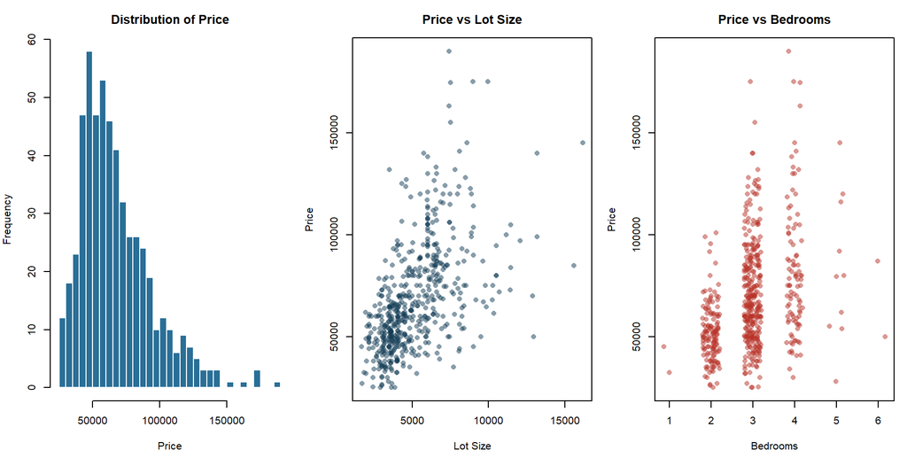

```r
# Three quick EDA views: response distribution, a strong continuous predictor,
# and a simple count predictor. These justify using multiple predictors later.
par(mfrow = c(1, 3), mar = c(4.5, 4, 3, 1))

hist(
  house.data$price,
  breaks = 30,
  col = "#2a6f97",
  border = "white",
  xlab = "Price",
  main = "Distribution of Price"
)

plot(
  house.data$lotsize,
  house.data$price,
  pch = 16,
  col = adjustcolor("#123c55", alpha.f = 0.5),
  xlab = "Lot Size",
  ylab = "Price",
  main = "Price vs Lot Size"
)

plot(
  jitter(house.data$bedrooms),
  house.data$price,
  pch = 16,
  col = adjustcolor("#b83227", alpha.f = 0.5),
  xlab = "Bedrooms",
  ylab = "Price",
  main = "Price vs Bedrooms"
)
```

```r
par(mfrow = c(1, 1), mar = c(5.1, 4.1, 4.1, 2.1))
```

- Price is right-skewed: most homes are modestly priced with a long tail of high-value sales.
- Lot size and price have a positive association, but with wide spread showing other features matter too.
- Bedroom count alone is a weak predictor — amenity combinations are more informative.

class: small-table

## HousePrices: Interim Process

```r
# Print the HousePrices workflow table created in the setup chunk.
kable(house.process, row.names = FALSE)
```

| Step | Detail |
| --- | --- |
| Split data | 448 train / 98 test |
| Create centered engineered terms | 8 derived/interaction candidates |
| Diagnose collinearity | 1 high-correlation pairs flagged; 0 pre-AIC removals |
| Build centered expanded full model | 19 centered starting predictors |
| Build model ladder | 19 nested steps |
| Run repeated CV | 5 folds x 6 repeats |
| Compare AIC and CV | Step 6 vs Step 9 |
| Remove outliers | 34 points above Cook cutoff |
| Rerun diagnostics and AIC/CV after Cook filtering | 1 post-Cook high-correlation pairs; Step 6 AIC and Step 6 CV |
| Check residuals | QQ, BP, and DW tests |
| Check Box-Cox transformation | profile plot and original-scale test metrics |
| Bootstrap intervals | 200 bootstrap resamples |
| Predict new homes | 2 cases with CI and PI |

- The ordering matters: choose the model on training data, check influential cases, rerun selection after filtering, then touch the held-out test set only once.
- Engineered terms and interactions are created before model selection, so AIC/CV can reject them instead of us deciding manually.

class: small-table compact

## HousePrices: VIF and Correlation Diagnostics

```r
# VIF and pairwise correlation are diagnostics. We do not use them as a hard
# filter because centered interaction and squared terms are supposed to remain
# related to their source variables.
kable(format_screen_summary(house.collinearity, "Initial training data"), row.names = FALSE)
```

| Stage | High Correlation Pairs | Max Adjusted VIF | Terms Sent to AIC/CV | Pre-AIC Removals |
| --- | --- | --- | --- | --- |
| Initial training data | 1 | 167.77 | 19 | None; AIC/CV selects from full centered set |

```r
kable(format_screen_summary(house.clean.collinearity, "Cook-filtered training data"), row.names = FALSE)
```

| Stage | High Correlation Pairs | Max Adjusted VIF | Terms Sent to AIC/CV | Pre-AIC Removals |
| --- | --- | --- | --- | --- |
| Cook-filtered training data | 1 | 163.23 | 19 | None; AIC/CV selects from full centered set |

```r
# Show the largest adjusted VIFs after Cook filtering, because that is the
# candidate set used by the final post-Cook selection ladder.
kable(format_final_vif_table(house.clean.collinearity, max_rows = 6), row.names = FALSE)
```

| Term | Adjusted VIF |
| --- | --- |
| lotsize_c | 163.23 |
| log_lotsize_c | 123.96 |
| lotsize_1000_c_sq | 13.43 |
| prefer:log_lotsize_c | 1.86 |
| garage_prefer_c | 1.74 |
| stories_c | 1.70 |

- VIF is used as a warning about coefficient stability, not as an automatic deletion rule.
- The expanded model still goes into AIC/CV intact because interactions and squared terms are correlated with their ingredients by design.
- Cook filtering is repeated before the final ladder, so the VIF picture matches the data used for the reported model.

class: plot-slide

## HousePrices: CV Across the Selection Ladder

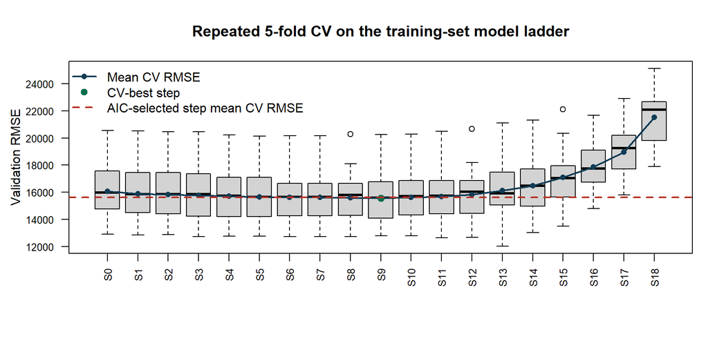

```r
# The boxplot shows all 30 validation RMSE values per ladder step; the blue
# line connects the mean CV RMSE for each step.
par(mar = c(7, 4.5, 4, 1))

boxplot(
  RMSE ~ factor(step_num, labels = house.cv.labels),
  data = house.cv,
  las = 2,
  cex.axis = 0.8,
  xlab = "",
  ylab = "Validation RMSE",
  main = "Repeated 5-fold CV on the training-set model ladder"
)

lines(seq_along(house.cv.labels), house.cv.summary$RMSE, col = "#123c55", lwd = 2)
points(seq_along(house.cv.labels), house.cv.summary$RMSE, pch = 16, col = "#123c55")
points(house.cv.best.idx, house.cv.summary$RMSE[house.cv.best.idx], pch = 19, col = "#0b6e4f", cex = 1.2)

abline(h = house.aic.cv.rmse, col = "#b83227", lty = 2, lwd = 2)
legend(
  "topleft",
  legend = c("Mean CV RMSE", "CV-best step", "AIC-selected step mean CV RMSE"),
  col = c("#123c55", "#0b6e4f", "#b83227"),
  pch = c(16, 19, NA),
  lty = c(1, NA, 2),
  lwd = c(2, NA, 2),
  bty = "n"
)
```

```r
par(mar = c(5.1, 4.1, 4.1, 2.1))
```

class: small-table

## HousePrices: AIC Step vs CV Step

```r
# Table version of the AIC-vs-CV decision for HousePrices.
kable(house.compare.display, row.names = FALSE)
```

| Model | Best Step | Predictors | CV RMSE |
| --- | --- | --- | --- |
| AIC-optimal | Step 6 | 13 | 15605.89 |
| CV-optimal | Step 9 | 10 | 15554.87 |

- AIC and CV are compared on the same training-set ladder.
- The held-out 20% test set is used only for the final check.
- For `HousePrices`, the CV gap is only 51.03, so the test flip of -71.96 is normal one-split noise rather than a contradiction.
- In practice, both criteria are pointing to nearly the same part of the ladder rather than arguing for very different housing models.

class: small-table

## HousePrices: Sensitivity to Cook Filtering

- We want to know if a few “weird” house sales are ruining our model.
- Imagine if someone sold a mansion for $1 — that one sale could throw off predictions for every other house.
- We use “Cook Filtering” to find and remove those kinds of sales, then check if it helped.

```r
kable(house.sensitivity.display, row.names = FALSE)
```

| Training Data Used | AIC Best Step | AIC RMSE | CV Best Step | CV RMSE |
| --- | --- | --- | --- | --- |
| Original training data | Step 6 | 15605.89 | Step 9 | 15554.87 |
| Cook-filtered training data | Step 6 | 11528.01 | Step 6 | 11528.01 |

```r
# Show a neat table of results in the slide.
# Each row is a different modeling setup:
#   - One using ALL sales, including odd/extreme ones
#   - One using CLEANED data after removing overly influential sales
# The table tells us, for each setup:
#   - Which step AIC thought was the best model (automatic model chooser)
#   - Which step cross-validation (CV) thought was the best (prediction-focused chooser)
#   - How big the typical prediction error was (RMSE: lower is better)
# So this table answers:
#   "Do weird sales change which model we pick, or mainly how accurate it is?"
```

- The upper table asks whether influential sales change model choice or mostly change the size of the validation error.
- We’re asking two questions about those weird sales: Question 1: Do they change WHICH model we end up choosing? Question 2: Do they just make our predictions less accurate? This matters because if removing them changes our whole model, that’s a big deal. If it just improves accuracy, that’s less serious.

```r
kable(house.test.display, row.names = FALSE)
```

| Training Data Used | AIC Best Step | CV Best Step | Held-out Test RMSE |
| --- | --- | --- | --- |
| Original training data | Step 6 | Step 9 | AIC 15658.57, CV 15586.61 |
| Cook-filtered training data | Step 6 | Step 6 | 15561.44 (same for AIC and CV) |

```r
# Show the performance on the TEST data.
# The test set is the 20% of houses we set aside at the start and did NOT use for training.
# This is like the final exam: it checks if our model can predict NEW houses it hasn't seen.
# The RMSE here is: "On average, how far off are we on these unseen houses?"
# If test RMSE is similar to validation RMSE, it suggests the model is not overfitted.
```

- In the upper table, both RMSE columns are repeated-CV validation RMSE. RMSE = how far off our predictions are on average (lower = better)
- In the lower table, the RMSE is computed on the held-out 20% test set by comparing predictions to the actual observed response values.
- When AIC and CV pick the same step, that test RMSE is shown once.
- After Cook filtering, the validation error drops without changing the overall selection story.

class: small-table plot-slide

## HousePrices: CV Ladder Before and After Cook Filtering

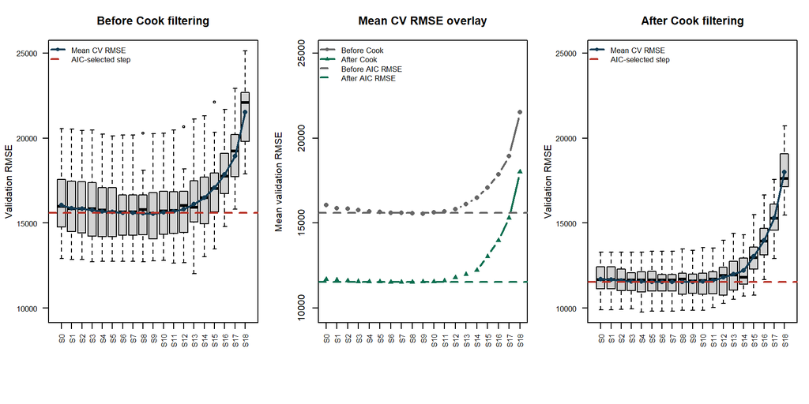

```r
par(mfrow = c(1, 3), mar = c(7, 4.2, 3.5, 1))
# Put 3 plots side by side:
#   Left: CV results BEFORE filtering
#   Middle: overlay of average errors before vs after
#   Right: CV results AFTER filtering

boxplot(
  RMSE ~ factor(step_num, labels = house.cv.labels),
  data = house.cv,
  las = 2,
  cex.axis = 0.8,
  xlab = "",
  ylab = "Validation RMSE",
  ylim = house.cv.ylim,
  main = "Before Cook filtering"
)
# Each box here shows the spread of prediction errors (RMSE) for a given model step,
# based on repeated cross-validation BEFORE we remove influential sales.
# Lower boxes mean better (more accurate) prediction.

lines(seq_len(nrow(house.cv.summary)), house.cv.summary$RMSE, col = "#123c55", lwd = 2)
points(seq_len(nrow(house.cv.summary)), house.cv.summary$RMSE, pch = 16, col = "#123c55")
# Overlay the average RMSE for each step as a connected line with points.


abline(h = house.aic.cv.rmse, col = "#b83227", lty = 2, lwd = 2)
# Horizontal dashed line at the RMSE of the model step chosen by AIC.
# This lets us see how that chosen model compares to others.

legend(
  "topleft",
  legend = c("Mean CV RMSE", "AIC-selected step"),
  col = c("#123c55", "#b83227"),
  pch = c(16, NA),
  lty = c(1, 2),
  lwd = c(2, 2),
  bty = "n",
  cex = 0.8
)
# Add a simple legend so the audience knows what the line and dashed line mean.


plot(
  house.cv.summary$step_num,
  house.cv.summary$RMSE,
  type = "b",
  pch = 16,
  lwd = 2,
  col = "gray40",
  xaxt = "n",
  xlab = "",
  ylab = "Mean validation RMSE",
  ylim = house.cv.ylim,
  main = "Mean CV RMSE overlay"
)
# Middle plot: just the mean RMSE for each model step BEFORE filtering.

lines(
  house.clean.cv.summary$step_num,
  house.clean.cv.summary$RMSE,
  type = "b",
  pch = 17,
  lwd = 2,
  col = "#0b6e4f"
)
# Add the AFTER-filtering mean RMSE as a second line.
# Seeing the green line lower than the gray line shows better prediction after filtering.

abline(h = house.aic.cv.rmse, col = "gray40", lty = 2, lwd = 2)
abline(h = house.clean.aic.cv.rmse, col = "#0b6e4f", lty = 2, lwd = 2)
# Dashed lines show the RMSEs for the AIC-chosen step before and after filtering.

axis(1, at = house.cv.summary$step_num, labels = house.cv.labels, las = 2, cex.axis = 0.8)
# Add readable labels for each step on the x-axis.

legend(
  "topleft",
  legend = c("Before Cook", "After Cook", "Before AIC RMSE", "After AIC RMSE"),
  col = c("gray40", "#0b6e4f", "gray40", "#0b6e4f"),
  pch = c(16, 17, NA, NA),
  lty = c(1, 1, 2, 2),
  lwd = c(2, 2, 2, 2),
  bty = "n",
  cex = 0.8
)
# Legend explains which line/point style is which.

boxplot(
  RMSE ~ factor(step_num, labels = house.clean.cv.labels),
  data = house.clean.cv,
  las = 2,
  cex.axis = 0.8,
  xlab = "",
  ylab = "Validation RMSE",
  ylim = house.cv.ylim,
  main = "After Cook filtering"
)
# Right plot: boxplots of RMSE for each step AFTER removing influential sales.
# We can compare these directly to the left plot to see if performance improved.

lines(seq_len(nrow(house.clean.cv.summary)), house.clean.cv.summary$RMSE, col = "#123c55", lwd = 2)
points(seq_len(nrow(house.clean.cv.summary)), house.clean.cv.summary$RMSE, pch = 16, col = "#123c55")
abline(h = house.clean.aic.cv.rmse, col = "#b83227", lty = 2, lwd = 2)
legend(
  "topleft",
  legend = c("Mean CV RMSE", "AIC-selected step"),
  col = c("#123c55", "#b83227"),
  pch = c(16, NA),
  lty = c(1, 2),
  lwd = c(2, 2),
  bty = "n",
  cex = 0.8
)
```

```r
# Again we show the average RMSE per step and the AIC-chosen step’s error.
# The important visual is: the whole set of boxes shifts downward after filtering.

par(mfrow = c(1, 1), mar = c(5.1, 4.1, 4.1, 2.1))
# Reset plotting layout back to the normal single-plot view.
```

- The whole ladder shifts down after filtering, so the influential cases were hurting validation performance across multiple candidate models.
- Because the whole curve moves down, Cook filtering improves model stability rather than just rescuing one lucky final step.

class: small-table compact

## HousePrices: Final Model Summary

- Final predictors kept:

  house.predictors is a character string listing the variables that stayed in the model.

  lotsize_c, bathrooms_c, stories_c, driveway, fullbase, gasheat, aircon, garage_c, prefer, log_lotsize_c, prefer:log_lotsize_c, aircon:log_lotsize_c, garage_c:lotsize_1000_c
- Removed from full model:

  house.removed.text lists the variables we tried initially but found not helpful enough.

  bedrooms_c, recreation, lotsize_1000_c_sq, bed_bath_c, bath_story_c, garage_prefer_c
- The idea: The first line is “what actually matters” for explaining price in the final model. The second line is “extra stuff” that did not improve prediction enough to keep.

```r
kable(house.summary, row.names = FALSE)
```

| Metric | Value |
| --- | --- |
| Selection Used | Post-Cook AIC/CV agreement |
| Adjusted R2 | 0.7434 |
| Residual s | 11277.06 |
| Outliers Removed | 34 |
| Test RMSE | 15561.44 |
| Test R2 | 0.6491 |

```r
# Display a compact summary of how well the final model performs.
# The table shows:
#   - Adjusted R2: how much of the variation in prices the model explains,
#                  adjusted for how many predictors we use.
#   - Residual s: the typical size of the errors on the training data,
#                 in the same units as price (lower is better).
#   - Outliers Removed: how many unusually influential sales we removed
#                       (via Cook filtering) before fitting this final model.
#   - Test RMSE: average prediction error on the 20% test set that the model
#                never saw during training (lower is better).
#   - Test R2: how much variation in prices the model explains on that test set.
# Together, these numbers give a high-level view of model fit and
# how well it predicts new house prices.
```

class: tiny-table compact small-title

## HousePrices: Final Model Terms

```r
# Coefficient table for the final HousePrices model, sorted by p-value.
kable(house.key, row.names = FALSE)
```

| Term | Estimate | P Value |
| --- | --- | --- |
| stories_c | 7805.6955 | < 1e-16 |
| bathrooms_c | 12852.9679 | < 1e-16 |
| airconyes | 9729.5636 | 7.14e-12 |
| preferyes | 9546.3443 | 2.94e-10 |
| fullbaseyes | 6006.3710 | 3.34e-06 |
| log_lotsize_c | 29548.4905 | 8.23e-06 |
| gasheatyes | 13901.8788 | 4.30e-05 |
| garage_c | 2565.4854 | 0.000541 |
| drivewayyes | 4261.8654 | 0.013657 |
| garage_c:lotsize_1000_c | 874.8578 | 0.022088 |
| lotsize_c | -2.3979 | 0.046558 |
| preferyes:log_lotsize_c | 5978.7046 | 0.071843 |
| airconyes:log_lotsize_c | 6490.6674 | 0.086865 |

- Larger lots, more stories and bathrooms, air conditioning, a garage, and preferred location all move fitted price upward when the other features are held fixed.
- The coefficient table shows that the strongest evidence sits in structural, amenity, and retained engineered terms rather than in one single dominant feature.

class: tiny-table compact small-title

## HousePrices: Engineered Terms Kept

```r
# Show every engineered HousePrices candidate that entered the expanded full
# model, then mark whether the post-Cook final model kept it.
house.engineered.pool <- c(house.derived.terms, house.interaction.terms)
house.final.terms <- get_model_terms(house.model.final)
house.selected.derived <- intersect(house.derived.terms, house.final.terms)
house.selected.interactions <- intersect(house.interaction.terms, house.final.terms)

house.engineered.status <- data.frame(
  Term = house.engineered.pool,
  Type = c(
    rep("Derived", length(house.derived.terms)),
    rep("Interaction", length(house.interaction.terms))
  ),
  Meaning = c(
    "Centered natural log of lot size.",
    "Squared centered lot size in thousands.",
    "Centered bedrooms multiplied by centered bathrooms.",
    "Centered bathrooms multiplied by centered stories.",
    "Centered garage spaces multiplied by preferred-neighborhood indicator.",
    "Centered log lot size slope allowed to differ by preferred-neighborhood status.",
    "Centered log lot size slope allowed to differ by air-conditioning status.",
    "Centered garage-space effect allowed to vary by centered lot size."
  ),
  `Kept In Final Model` = ifelse(house.engineered.pool %in% house.final.terms, "Yes", "No"),
  check.names = FALSE
)

kable(house.engineered.status, row.names = FALSE)
```

[output not shown]

- AIC/CV considered these terms from the start; they were not pasted on after the final model was chosen.
- Retained derived terms mean the house-price relationship is not purely linear in the original variables.
- Retained interactions mean at least one housing feature changes slope depending on another feature or amenity.

class: plot-slide small-table

## HousePrices: Diagnostics

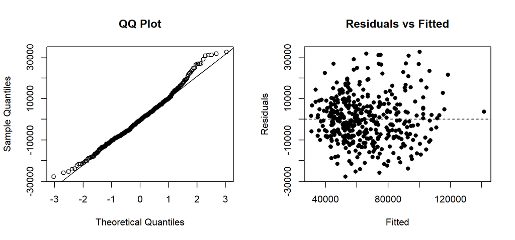

```r
# Visual residual checks: normality with QQ plot and equal-variance pattern
# with residuals vs fitted values.
par(mfrow = c(1, 2))
qqnorm(house.model.final$residuals, main = "QQ Plot")
qqline(house.model.final$residuals)
plot(
  house.model.final$fitted.values,
  house.model.final$residuals,
  pch = 16,
  xlab = "Fitted",
  ylab = "Residuals",
  main = "Residuals vs Fitted"
)
abline(h = 0, lty = "dashed")
```

```r
par(mfrow = c(1, 1))
```

```r
# Formal diagnostic p-values corresponding to the residual-check slide.
kable(house.diag, row.names = FALSE)
```

| Test | P.Value |
| --- | --- |
| Shapiro-Wilk | 0.0035 |
| Breusch-Pagan | 0.0353 |
| Durbin-Watson | 5.95e-07 |

- The residual checks do not show a single breakdown large enough to undermine the model for the main inference and prediction goals here.

class: small-table plot-slide compact

## HousePrices: Box-Cox Response Check

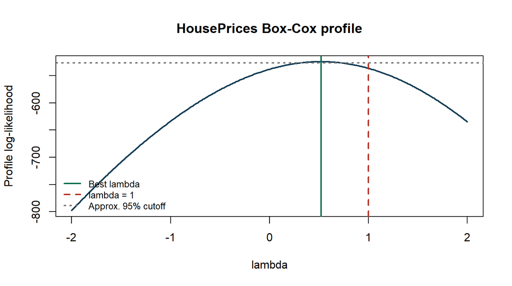

```r
# Box-Cox profiles possible response transformations. Lambda = 1 corresponds
# to no transformation, so its location relative to the 95% cutoff determines
# whether the profile plot gives transformation evidence.
house.boxcox <- boxcox_fit_and_evaluate(
  house.model.final,
  house.train.new,
  house.test,
  "price",
  "HousePrices"
)

plot_boxcox_profile(house.boxcox$profile, "HousePrices Box-Cox profile")
```

```r
# Compare on the original price scale so the transformed-response model is not
# rewarded just for changing units.
kable(boxcox_decision_table(
  house.boxcox,
  ifelse(
    house.boxcox$profile$identity.in.interval,
    "Keep original price scale; lambda = 1 remains plausible.",
    "Report as sensitivity evidence; lambda = 1 is outside the profile interval."
  )
), row.names = FALSE)
```

| Best Lambda | Approx. 95% Lambda Interval | Lambda 1 In Interval | Decision |
| --- | --- | --- | --- |
| 0.52 | [0.33, 0.7] | FALSE | Report as sensitivity evidence; lambda = 1 is outside the profile interval. |

- The profile peaks near lambda 0.52; lambda = 1 is outside the approximate 95% interval.
- We keep the original-scale model as the main result when interpretability and held-out performance are comparable; Box-Cox is the assumption sensitivity check.

class: small-table compact

## HousePrices: Box-Cox Test Metrics

```r
# These rows compare final-model predictions on the held-out test set after
# converting any Box-Cox prediction back to dollar scale.
kable(boxcox_performance_table(house.boxcox), row.names = FALSE)
```

| Dataset | Model | Lambda | Test R2 | Test RMSE | Shapiro P | BP P |
| --- | --- | --- | --- | --- | --- | --- |
| HousePrices | Current final | NA | 0.6491 | 15561.44 | 0.0035 | 0.0353 |
| HousePrices | Box-Cox naive back-transform | 0.52 | 0.6532 | 15470.60 | 0.5007 | 0.5137 |
| HousePrices | Box-Cox smearing back-transform | 0.52 | 0.6522 | 15493.34 | 0.5007 | 0.5137 |

- The comparison is made on the original price scale, so RMSE remains interpretable as average dollar prediction error.
- The smearing version corrects the back-transform for residual spread on the transformed scale.
- We treat Box-Cox as a sensitivity model unless it clearly improves held-out RMSE and keeps interpretation acceptable.

class: plot-slide

## HousePrices: Bootstrap Coefficient Intervals

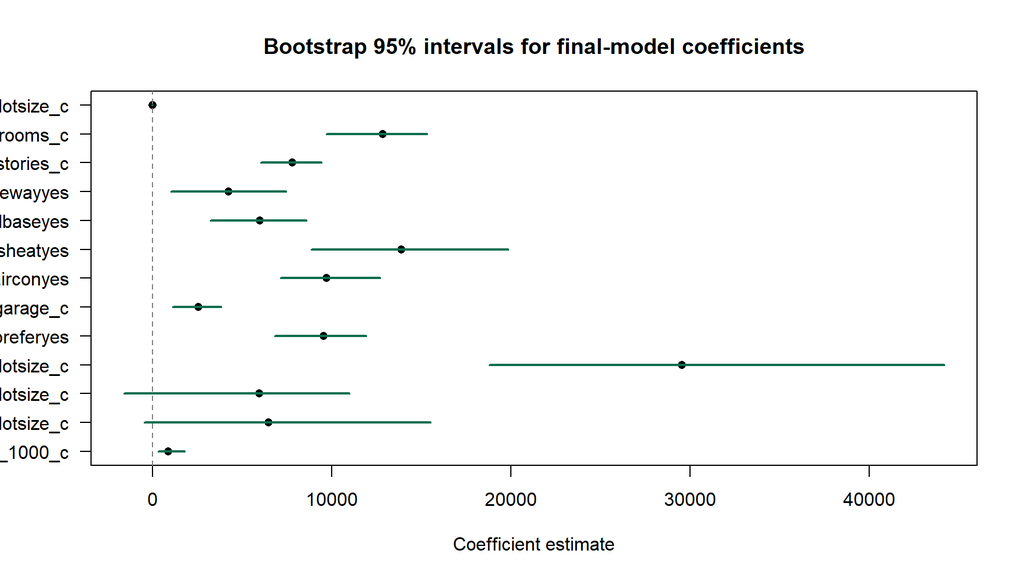

```r
# Prepare the bootstrap coefficient interval plot. The intercept is removed
# because it is on a much larger scale than the predictor coefficients.
house.boot.plot <- subset(house.boot, term != "(Intercept)")
house.boot.plot <- house.boot.plot[nrow(house.boot.plot):1, ]

plot(
  house.boot.plot$estimate,
  seq_len(nrow(house.boot.plot)),
  xlim = range(c(house.boot.plot$lower, house.boot.plot$upper)),
  pch = 16,
  yaxt = "n",
  ylab = "",
  xlab = "Coefficient estimate",
  main = "Bootstrap 95% intervals for final-model coefficients"
)

segments(
  house.boot.plot$lower, seq_len(nrow(house.boot.plot)),
  house.boot.plot$upper, seq_len(nrow(house.boot.plot)),
  lwd = 2,
  col = "#0b6e4f"
)

abline(v = 0, lty = "dashed", col = "gray50")
axis(2, at = seq_len(nrow(house.boot.plot)), labels = house.boot.plot$term, las = 2)
```

- These are empirical 95% intervals from `200` bootstrap resamples of the final training set.
- Intervals far from `0` support stable coefficient direction.
- The intercept is omitted because its much larger scale would compress the predictor effects.
- The most practically important retained terms stay on one side of `0`, which supports stable sign interpretation.

class: small-table

## HousePrices: Prediction Examples

```r
# Show fitted values, confidence intervals, and prediction intervals for the
# two manually defined house examples.
kable(house.pred.table, row.names = FALSE)
```

| Scenario | Fit | CI | PI |
| --- | --- | --- | --- |
| Smaller home | 49203 | (46814, 51593) | (26905, 71502) |
| Larger home | 130632 | (122694, 138570) | (107084, 154180) |

- The confidence interval estimates the mean price.
- The prediction interval is wider because it predicts an individual home sale.
- The higher-amenity scenario also gets the higher fitted price, which matches the coefficient signs in the final model.

class: plot-slide

## HousePrices: CI and PI Overlay

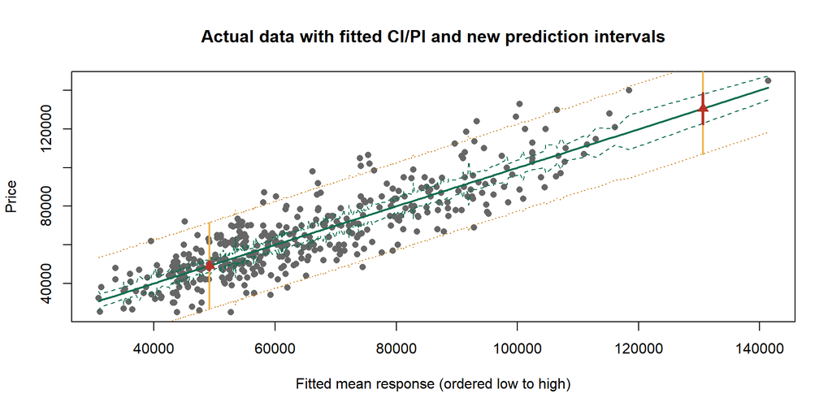

```r
# Overlay fitted means, CIs, and PIs on the actual cleaned training data.
# New prediction examples are plotted at their fitted x-location.
plot(
  house.fit.x,
  house.train.new$price[house.order],
  pch = 16,
  col = "gray40",
  xlab = "Fitted mean response (ordered low to high)",
  ylab = "Price",
  main = "Actual data with fitted CI/PI and new prediction intervals"
)

lines(house.fit.x, house.fit.x, col = "#0b6e4f", lwd = 2)
lines(house.fit.x, house.actual.conf[house.order, "lwr"], col = "#0b6e4f", lty = 2)
lines(house.fit.x, house.actual.conf[house.order, "upr"], col = "#0b6e4f", lty = 2)
lines(house.fit.x, house.actual.pred[house.order, "lwr"], col = "#c97c10", lty = 3)
lines(house.fit.x, house.actual.pred[house.order, "upr"], col = "#c97c10", lty = 3)

points(house.new.fit, house.new.fit, pch = 17, col = "#b83227", cex = 1.3)
segments(house.new.fit, house.pred[, "lwr"], house.new.fit, house.pred[, "upr"],
         col = "#f0b44c", lwd = 2)
segments(house.new.fit, house.conf[, "lwr"], house.new.fit, house.conf[, "upr"],
         col = "#b83227", lwd = 3)
```

- Gray points are actual observed prices.
- The x-axis is fitted mean response, sorted from low to high.
- The green line is the fitted mean.
- Orange bands show PI for observed-data rows.
- Red triangles and bars now sit at their fitted locations on the green line.
- The wider orange bands show that individual-home prediction is much harder than estimating the mean response.

class: plot-slide

## HousePrices: Predicted vs Actual (Test Set)

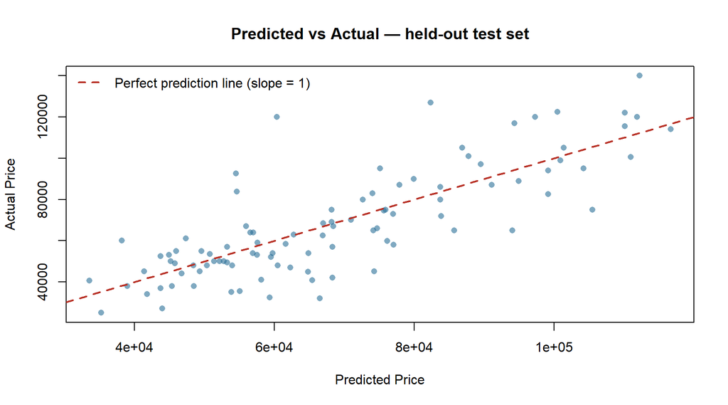

```r
# Final visual check on the held-out test set: points near the 45-degree line
# are accurate predictions.
plot(
  house.prediction,
  house.test$price,
  pch = 16,
  col = adjustcolor("#2a6f97", alpha.f = 0.6),
  xlab = "Predicted Price",
  ylab = "Actual Price",
  main = "Predicted vs Actual — held-out test set"
)
abline(0, 1, col = "#b83227", lwd = 2, lty = 2)
legend(
  "topleft",
  legend = "Perfect prediction line (slope = 1)",
  col = "#b83227",
  lty = 2,
  lwd = 2,
  bty = "n"
)
```

- Points close to the dashed line indicate accurate test-set predictions.
- Deviations are largest at high price values, showing more uncertainty for expensive homes.
- The overall scatter is consistent with the test RMSE reported in the final model summary.

## CASchools: Dataset Snapshot

.pull-left[ - `420` observations and `9` original analysis variables - Response: average test score `score` - `str`: students per teacher - `calworks`: percent of students on CalWORKs - `lunch`: percent eligible for subsidized lunch - `income`: district income level - `english`: percent of English learners - `grades`: district grade-span category; one fitted indicator is `gradesKK-08` for K-8 districts - Missing values: `0` - Centered variables, squared terms, and socioeconomic interactions are created after the train/test split. - The covariates mix school resources with student-composition measures, so the model is mainly explanatory rather than causal.]

.pull-right[

```r
# Simple dataset-audit table for the transformed CASchools analysis data.
kable(
  data.frame(
    Item = c("Rows", "Columns after engineering", "Missing"),
    Value = c(nrow(schools.data), ncol(schools.data), sum(is.na(schools.data)))
  ),
  row.names = FALSE
)
```

| Item | Value |
| --- | --- |
| Rows | 420 |
| Columns after engineering | 22 |
| Missing | 0 |

]

class: plot-slide

## CASchools: Exploratory Overview

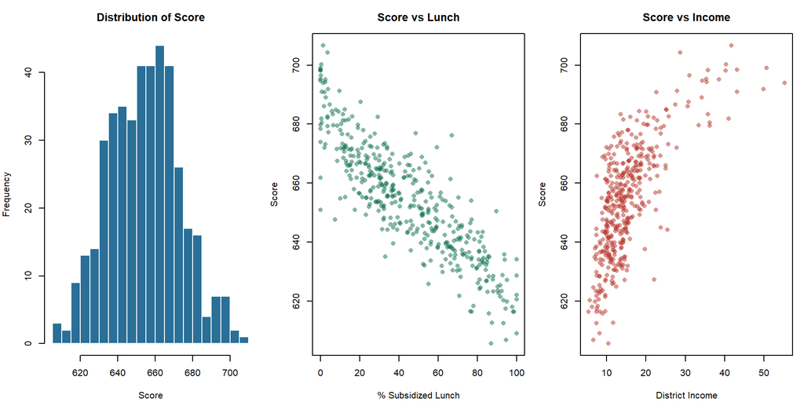

```r
# EDA focuses on the response and the two strongest socioeconomic patterns:
# subsidized lunch share and district income.
par(mfrow = c(1, 3), mar = c(4.5, 4, 3, 1))

hist(
  schools.data$score,
  breaks = 25,
  col = "#2a6f97",
  border = "white",
  xlab = "Score",
  main = "Distribution of Score"
)

plot(
  schools.data$lunch,
  schools.data$score,
  pch = 16,
  col = adjustcolor("#0b6e4f", alpha.f = 0.5),
  xlab = "% Subsidized Lunch",
  ylab = "Score",
  main = "Score vs Lunch"
)

plot(
  schools.data$income,
  schools.data$score,
  pch = 16,
  col = adjustcolor("#b83227", alpha.f = 0.5),
  xlab = "District Income",
  ylab = "Score",
  main = "Score vs Income"
)
```

```r
par(mfrow = c(1, 1), mar = c(5.1, 4.1, 4.1, 2.1))
```

- Score is roughly symmetric and bell-shaped across districts.
- The negative relationship with lunch rate is the strongest raw signal in the data.
- Income shows a clear positive association, confirming that socioeconomic factors dominate the score pattern.

class: small-table

## CASchools: Interim Process

```r
# Print the CASchools workflow table created in the setup chunk.
kable(schools.process, row.names = FALSE)
```

| Step | Detail |
| --- | --- |
| Split data | 324 train / 96 test |
| Create centered engineered terms | 10 derived/interaction candidates |
| Diagnose collinearity | 0 high-correlation pairs flagged; 0 pre-AIC removals |
| Build centered expanded full model | 18 centered starting predictors |
| Build model ladder | 18 nested steps |
| Run repeated CV | 5 folds x 6 repeats |
| Compare AIC and CV | Step 12 vs Step 12 |
| Remove outliers | 19 points above Cook cutoff |
| Rerun diagnostics and AIC/CV after Cook filtering | 0 post-Cook high-correlation pairs; Step 12 AIC and Step 12 CV |
| Check residuals | QQ, BP, and DW tests |
| Check Box-Cox transformation | profile plot and original-scale test metrics |
| Bootstrap intervals | 200 bootstrap resamples |
| Predict districts | 2 cases with CI and PI |

- The main question is whether school-score variation is driven more by student composition than by resource variables.
- Engineered socioeconomic terms are included before AIC/CV, so nonlinear and interaction patterns must earn their place in the selected model.

class: small-table compact

## CASchools: VIF and Correlation Diagnostics

```r
# Correlation and VIF show redundancy risk in the expanded school-score
# candidate set. They are diagnostics only, not a pre-AIC filter.
kable(format_screen_summary(schools.collinearity, "Initial training data"), row.names = FALSE)
```

| Stage | High Correlation Pairs | Max Adjusted VIF | Terms Sent to AIC/CV | Pre-AIC Removals |
| --- | --- | --- | --- | --- |
| Initial training data | 0 | 42.82 | 18 | None; AIC/CV selects from full centered set |

```r
kable(format_screen_summary(schools.clean.collinearity, "Cook-filtered training data"), row.names = FALSE)
```

| Stage | High Correlation Pairs | Max Adjusted VIF | Terms Sent to AIC/CV | Pre-AIC Removals |
| --- | --- | --- | --- | --- |
| Cook-filtered training data | 0 | 39.91 | 18 | None; AIC/CV selects from full centered set |

```r
# Final VIFs are shown after Cook filtering because that is the training data
# used to build the reported final model.
kable(format_final_vif_table(schools.clean.collinearity, max_rows = 6), row.names = FALSE)
```

| Term | Adjusted VIF |
| --- | --- |
| lunch_c | 39.91 |
| english_c | 37.53 |
| english_c:grades | 36.93 |
| lunch_c:grades | 35.03 |
| income_c | 19.85 |
| income_c:grades | 15.48 |

- Higher VIFs are expected when socioeconomic variables, squares, and interactions describe overlapping district conditions.
- We document the redundancy, then let AIC/CV decide whether any engineered term improves prediction enough to keep.
- This avoids deleting interaction terms just because they are naturally correlated with the variables that created them.

class: plot-slide

## CASchools: CV Across the Selection Ladder

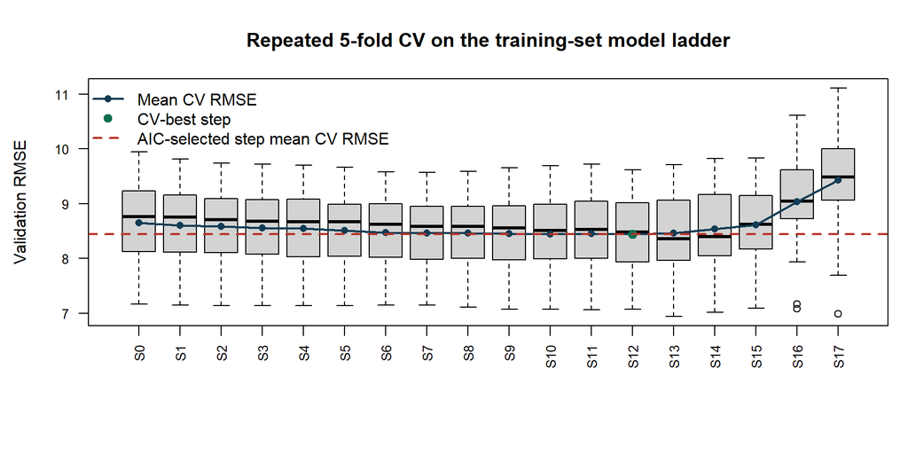

```r
# Same CV ladder idea as HousePrices: each box contains 30 validation RMSEs
# for one model step, and the line shows the average across those folds.
par(mar = c(7, 4.5, 4, 1))

boxplot(
  RMSE ~ factor(step_num, labels = schools.cv.labels),
  data = schools.cv,
  las = 2,
  cex.axis = 0.8,
  xlab = "",
  ylab = "Validation RMSE",
  main = "Repeated 5-fold CV on the training-set model ladder"
)

lines(seq_along(schools.cv.labels), schools.cv.summary$RMSE, col = "#123c55", lwd = 2)
points(seq_along(schools.cv.labels), schools.cv.summary$RMSE, pch = 16, col = "#123c55")
points(schools.cv.best.idx, schools.cv.summary$RMSE[schools.cv.best.idx], pch = 19, col = "#0b6e4f", cex = 1.2)

abline(h = schools.aic.cv.rmse, col = "#b83227", lty = 2, lwd = 2)
legend(
  "topleft",
  legend = c("Mean CV RMSE", "CV-best step", "AIC-selected step mean CV RMSE"),
  col = c("#123c55", "#0b6e4f", "#b83227"),
  pch = c(16, 19, NA),
  lty = c(1, NA, 2),
  lwd = c(2, NA, 2),
  bty = "n"
)
```

```r
par(mar = c(5.1, 4.1, 4.1, 2.1))
```

- The ladder is built from the training-set full model.
- Each step again summarizes `30` validation RMSE values from `5` folds repeated `6` times.
- This checks whether a simpler school-score model is competitive before touching the test set.
- Here the AIC step and CV step agree, so the red line lands at the best step.
- Agreement between AIC and CV makes the reduced school model much more defensible.

class: small-table

## CASchools: AIC Step vs CV Step

```r
# Table version of the AIC-vs-CV decision for CASchools.
kable(schools.compare.display, row.names = FALSE)
```

| Model | Best Step | Predictors | CV RMSE |
| --- | --- | --- | --- |
| AIC-optimal | Step 12 | 6 | 8.444 |
| CV-optimal | Step 12 | 6 | 8.444 |

- The agreement here says the AIC-selected reduction is not just an artifact of one criterion.

class: small-table

## CASchools: Sensitivity to Cook Filtering

```r
# Validation sensitivity table: compares repeated-CV RMSE before and after
# influential districts are removed from the training data.
kable(schools.sensitivity.display, row.names = FALSE)
```

| Training Data Used | AIC Best Step | AIC RMSE | CV Best Step | CV RMSE |
| --- | --- | --- | --- | --- |
| Original training data | Step 12 | 8.44 | Step 12 | 8.44 |
| Cook-filtered training data | Step 12 | 7.14 | Step 12 | 7.14 |

- The main question is whether influential districts materially change the selected CV step or the full validation curve.

```r
# Held-out test table: final prediction check on the 20% test set.
kable(schools.test.display, row.names = FALSE)
```

| Training Data Used | AIC Best Step | CV Best Step | Held-out Test RMSE |
| --- | --- | --- | --- |
| Original training data | Step 12 | Step 12 | 8.39 (same for AIC and CV) |
| Cook-filtered training data | Step 12 | Step 12 | 8.40 (same for AIC and CV) |

- In the upper table, both RMSE columns are repeated-CV validation RMSE.
- In the lower table, the RMSE is computed on the held-out 20% test set by comparing predictions to the actual observed response values.
- When AIC and CV pick the same step, that test RMSE is shown once.
- The selected step does not move after filtering, so the main school result is not being driven by a few extreme districts.

class: small-table plot-slide

## CASchools: CV Ladder Before and After Cook Filtering

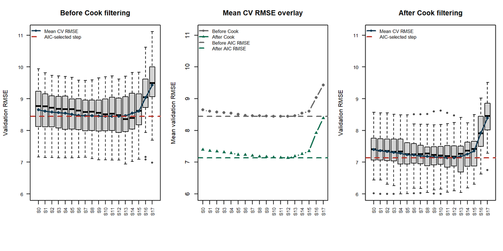

```r
# Same before/after Cook-filtering plot structure used for HousePrices. The
# shared y-axis makes the validation-error change visually comparable.
par(mfrow = c(1, 3), mar = c(7, 4.2, 3.5, 1))

boxplot(
  RMSE ~ factor(step_num, labels = schools.cv.labels),
  data = schools.cv,
  las = 2,
  cex.axis = 0.8,
  xlab = "",
  ylab = "Validation RMSE",
  ylim = schools.cv.ylim,
  main = "Before Cook filtering"
)
lines(seq_len(nrow(schools.cv.summary)), schools.cv.summary$RMSE, col = "#123c55", lwd = 2)
points(seq_len(nrow(schools.cv.summary)), schools.cv.summary$RMSE, pch = 16, col = "#123c55")
abline(h = schools.aic.cv.rmse, col = "#b83227", lty = 2, lwd = 2)
legend(
  "topleft",
  legend = c("Mean CV RMSE", "AIC-selected step"),
  col = c("#123c55", "#b83227"),
  pch = c(16, NA),
  lty = c(1, 2),
  lwd = c(2, 2),
  bty = "n",
  cex = 0.8
)

plot(
  schools.cv.summary$step_num,
  schools.cv.summary$RMSE,
  type = "b",
  pch = 16,
  lwd = 2,
  col = "gray40",
  xaxt = "n",
  xlab = "",
  ylab = "Mean validation RMSE",
  ylim = schools.cv.ylim,
  main = "Mean CV RMSE overlay"
)
lines(
  schools.clean.cv.summary$step_num,
  schools.clean.cv.summary$RMSE,
  type = "b",
  pch = 17,
  lwd = 2,
  col = "#0b6e4f"
)
abline(h = schools.aic.cv.rmse, col = "gray40", lty = 2, lwd = 2)
abline(h = schools.clean.aic.cv.rmse, col = "#0b6e4f", lty = 2, lwd = 2)
axis(1, at = schools.cv.summary$step_num, labels = schools.cv.labels, las = 2, cex.axis = 0.8)
legend(
  "topleft",
  legend = c("Before Cook", "After Cook", "Before AIC RMSE", "After AIC RMSE"),
  col = c("gray40", "#0b6e4f", "gray40", "#0b6e4f"),
  pch = c(16, 17, NA, NA),
  lty = c(1, 1, 2, 2),
  lwd = c(2, 2, 2, 2),
  bty = "n",
  cex = 0.8
)

boxplot(
  RMSE ~ factor(step_num, labels = schools.clean.cv.labels),
  data = schools.clean.cv,
  las = 2,
  cex.axis = 0.8,
  xlab = "",
  ylab = "Validation RMSE",
  ylim = schools.cv.ylim,
  main = "After Cook filtering"
)
lines(seq_len(nrow(schools.clean.cv.summary)), schools.clean.cv.summary$RMSE, col = "#123c55", lwd = 2)
points(seq_len(nrow(schools.clean.cv.summary)), schools.clean.cv.summary$RMSE, pch = 16, col = "#123c55")
abline(h = schools.clean.aic.cv.rmse, col = "#b83227", lty = 2, lwd = 2)
legend(
  "topleft",
  legend = c("Mean CV RMSE", "AIC-selected step"),
  col = c("#123c55", "#b83227"),
  pch = c(16, NA),
  lty = c(1, 2),
  lwd = c(2, 2),
  bty = "n",
  cex = 0.8
)
```

```r
par(mfrow = c(1, 1), mar = c(5.1, 4.1, 4.1, 2.1))
```

- The best step stays the same after Cook filtering, but the full curve shifts down, which makes the selected model look more stable.
- That means filtering helps fit quality, but it does not change which predictors matter.

class: tiny-table compact

## CASchools: Final Model

- Final predictors kept:

lunch_c, computer.rate_c, income_c, english_c, grades, low_income_pressure_c

- Removed from full model:

str_c, calworks_c, expenditure_c, income_c_sq, lunch_c_sq, english_c_sq, income_lunch_c, str_lunch_c, lunch_c:grades, income_c:grades, english_c:grades, str_c:grades

.pull-left[

```r
# Left table gives overall final-model fit and held-out test performance.
kable(schools.summary, row.names = FALSE)
```

| Metric | Value |
| --- | --- |
| Selection Used | Post-Cook AIC/CV agreement |
| Adjusted R2 | 0.8485 |
| Residual s | 7.04 |
| Outliers Removed | 19 |
| Test RMSE | 8.4 |
| Test R2 | 0.819 |

]

.pull-right[

```r
# Right table gives final-model coefficient estimates and p-values.
kable(schools.key, row.names = FALSE)
```

| Term | Estimate | P Value |
| --- | --- | --- |
| lunch_c | -0.3424 | < 1e-16 |
| income_c | 0.7782 | 5.09e-15 |
| english_c | -0.3031 | 2.32e-11 |
| gradesKK-08 | -3.8886 | 0.00117 |
| low_income_pressure_c | 0.0029 | 0.00658 |
| computer.rate_c | 18.1300 | 0.00773 |

]

- `gradesKK-08` is kept in the pooled model because it captures a real district-type difference; dropping it would likely push that effect into the other coefficients.
- The model-selection process also saw squared and interaction terms, so omitted engineered terms are evidence that their extra complexity did not improve the post-Cook ladder enough.
- Once poverty proxies and district type are in the model, extra resource variables add much less explanatory power.

class: tiny-table compact small-title

## CASchools: Engineered Terms Kept

```r
# Show the engineered CASchools candidates and whether they survived the final
# post-Cook model-selection process.
schools.engineered.pool <- c(schools.derived.terms, schools.interaction.terms)
schools.final.terms <- get_model_terms(schools.model.final)
schools.selected.derived <- intersect(schools.derived.terms, schools.final.terms)
schools.selected.interactions <- intersect(schools.interaction.terms, schools.final.terms)

schools.engineered.status <- data.frame(
  Term = schools.engineered.pool,
  Type = c(
    rep("Derived", length(schools.derived.terms)),
    rep("Interaction", length(schools.interaction.terms))
  ),
  Meaning = c(
    "Squared centered district income.",
    "Squared centered subsidized-lunch percentage.",
    "Squared centered English-learner percentage.",
    "Centered lunch percentage multiplied by centered English-learner percentage.",
    "Centered income multiplied by centered lunch percentage.",
    "Centered student-teacher ratio multiplied by centered lunch percentage.",
    "Centered lunch slope allowed to differ by district grade span.",
    "Centered income slope allowed to differ by district grade span.",
    "Centered English-learner slope allowed to differ by district grade span.",
    "Centered student-teacher-ratio slope allowed to differ by district grade span."
  ),
  `Kept In Final Model` = ifelse(schools.engineered.pool %in% schools.final.terms, "Yes", "No"),
  check.names = FALSE
)

kable(schools.engineered.status, row.names = FALSE)
```

| Term | Type | Meaning | Kept In Final Model |
| --- | --- | --- | --- |
| income_c_sq | Derived | Squared centered district income. | No |
| lunch_c_sq | Derived | Squared centered subsidized-lunch percentage. | No |
| english_c_sq | Derived | Squared centered English-learner percentage. | No |
| low_income_pressure_c | Interaction | Centered lunch percentage multiplied by centered English-learner percentage. | Yes |
| income_lunch_c | Interaction | Centered income multiplied by centered lunch percentage. | No |
| str_lunch_c | Interaction | Centered student-teacher ratio multiplied by centered lunch percentage. | No |
| lunch_c:grades | Interaction | Centered lunch slope allowed to differ by district grade span. | No |
| income_c:grades | Interaction | Centered income slope allowed to differ by district grade span. | No |
| english_c:grades | Interaction | Centered English-learner slope allowed to differ by district grade span. | No |
| str_c:grades | Interaction | Centered student-teacher-ratio slope allowed to differ by district grade span. | No |

- CASchools is the stronger case for socioeconomic nonlinearities because poverty, income, and English-learner share overlap in the raw data.
- Retained derived or interaction terms mean those patterns explain score variation beyond the original centered main effects.
- Rejected engineered terms are still useful: they show AIC/CV did not need every possible curve or district-specific slope.

class: plot-slide small-table

## CASchools: Diagnostics

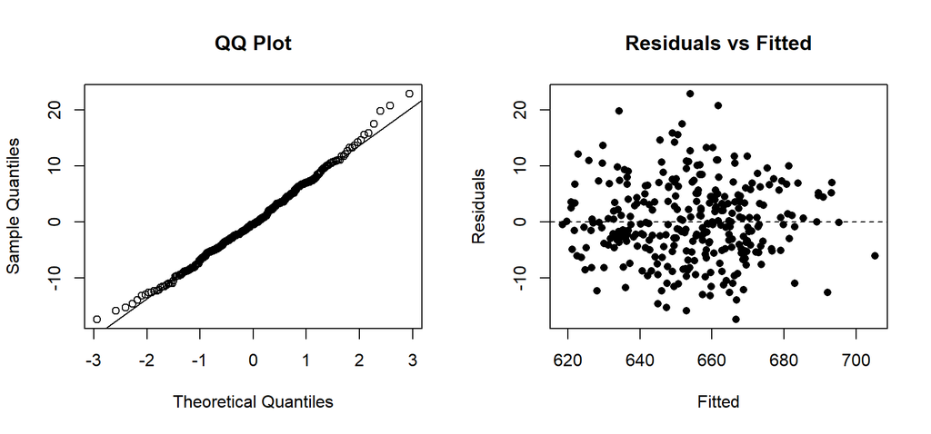

```r
# Visual residual checks for the final CASchools model.
par(mfrow = c(1, 2))
qqnorm(schools.model.final$residuals, main = "QQ Plot")
qqline(schools.model.final$residuals)
plot(
  schools.model.final$fitted.values,
  schools.model.final$residuals,
  pch = 16,
  xlab = "Fitted",
  ylab = "Residuals",
  main = "Residuals vs Fitted"
)
abline(h = 0, lty = "dashed")
```

```r
par(mfrow = c(1, 1))
```

```r
# Formal diagnostic p-values corresponding to the visual residual checks.
kable(schools.diag, row.names = FALSE)
```

| Test | P.Value |
| --- | --- |
| Shapiro-Wilk | 0.37430 |
| Breusch-Pagan | 0.35933 |
| Durbin-Watson | 0.00814 |

- The residual diagnostics are acceptable for this project; the larger interpretive question is coefficient meaning, not obvious model failure.

class: small-table plot-slide compact

## CASchools: Box-Cox Response Check

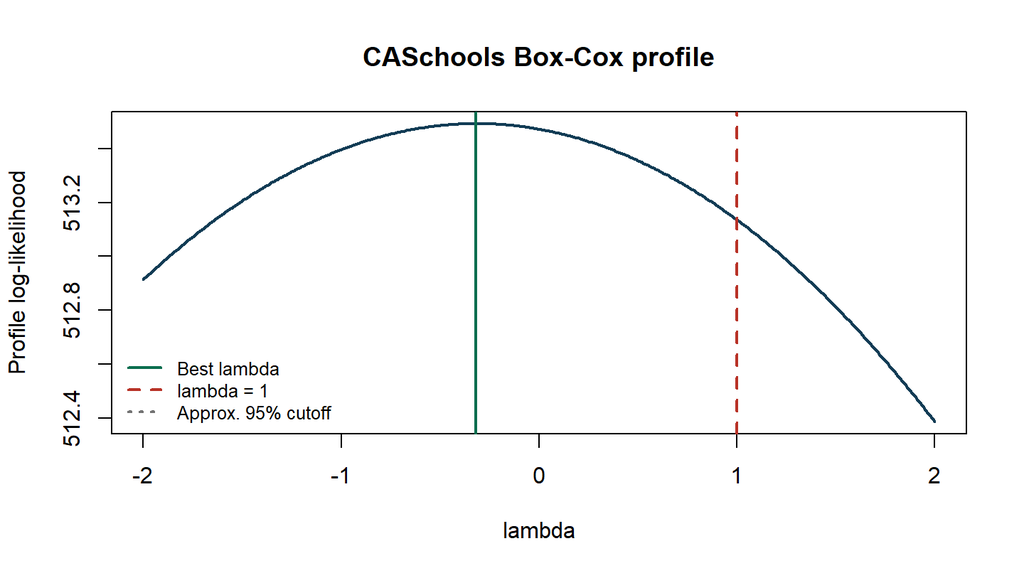

```r
# For CASchools, Box-Cox checks whether transforming the average score response
# materially improves assumptions. Lambda = 1 means keeping the original score
# scale.
schools.boxcox <- boxcox_fit_and_evaluate(
  schools.model.final,
  schools.train.new,
  schools.test,
  "score",
  "CASchools"
)

plot_boxcox_profile(schools.boxcox$profile, "CASchools Box-Cox profile")
```

```r
# The decision is based on the profile interval plus whether original-scale
# held-out performance changes enough to justify harder interpretation.
kable(boxcox_decision_table(
  schools.boxcox,
  ifelse(
    schools.boxcox$profile$identity.in.interval,
    "Keep original score scale; lambda = 1 remains plausible.",
    "Use/report Box-Cox as sensitivity evidence; lambda = 1 is outside the profile interval."
  )
), row.names = FALSE)
```

| Best Lambda | Approx. 95% Lambda Interval | Lambda 1 In Interval | Decision |
| --- | --- | --- | --- |
| -0.32 | [-2, 2] | TRUE | Keep original score scale; lambda = 1 remains plausible. |

- The profile peaks near lambda -0.32; lambda = 1 is inside the approximate 95% interval.
- Because test score is naturally interpretable, Box-Cox would need clear diagnostic and prediction gains before replacing the original response.

class: small-table compact

## CASchools: Box-Cox Test Metrics

```r
# Compare original-scale held-out performance for the current final model and
# the Box-Cox alternatives.
kable(boxcox_performance_table(schools.boxcox), row.names = FALSE)
```

| Dataset | Model | Lambda | Test R2 | Test RMSE | Shapiro P | BP P |
| --- | --- | --- | --- | --- | --- | --- |
| CASchools | Current final | NA | 0.8190 | 8.40 | 0.374 | 0.359 |
| CASchools | Box-Cox naive back-transform | -0.32 | 0.8194 | 8.39 | 0.420 | 0.301 |
| CASchools | Box-Cox smearing back-transform | -0.32 | 0.8190 | 8.40 | 0.420 | 0.301 |

- RMSE is still measured in test-score points after back-transforming.
- If the Box-Cox rows do not meaningfully improve held-out RMSE, the original score scale is easier to defend in presentation.
- The diagnostic value is still useful because it shows we checked the response-transformation assumption rather than ignoring it.

class: plot-slide

## CASchools: Bootstrap Coefficient Intervals

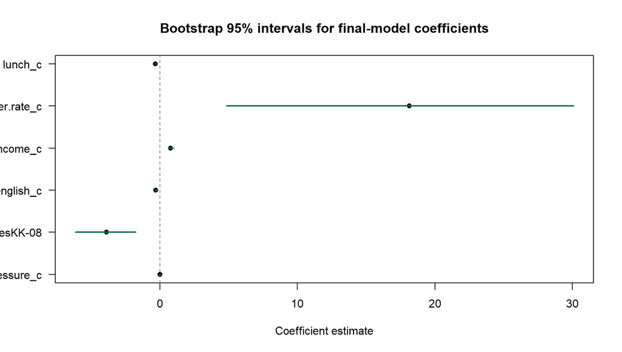

```r
# Prepare the bootstrap coefficient interval plot for CASchools.
schools.boot.plot <- subset(schools.boot, term != "(Intercept)")
schools.boot.plot <- schools.boot.plot[nrow(schools.boot.plot):1, ]

plot(
  schools.boot.plot$estimate,
  seq_len(nrow(schools.boot.plot)),
  xlim = range(c(schools.boot.plot$lower, schools.boot.plot$upper)),
  pch = 16,
  yaxt = "n",
  ylab = "",
  xlab = "Coefficient estimate",
  main = "Bootstrap 95% intervals for final-model coefficients"
)

segments(
  schools.boot.plot$lower, seq_len(nrow(schools.boot.plot)),
  schools.boot.plot$upper, seq_len(nrow(schools.boot.plot)),
  lwd = 2,
  col = "#0b6e4f"
)

abline(v = 0, lty = "dashed", col = "gray50")
axis(2, at = seq_len(nrow(schools.boot.plot)), labels = schools.boot.plot$term, las = 2)
```

- These are empirical 95% intervals from `200` bootstrap resamples.
- A log scale would not work here because several coefficients are negative.
- The intercept is omitted so the predictor intervals do not collapse visually toward `0`.
- `lunch` and `income` remain the most stable effects, while weaker terms sit closer to `0` and deserve more caution.

class: small-table

## CASchools: Prediction Examples

```r
# Show fitted values, confidence intervals, and prediction intervals for the
# two manually defined district examples.
kable(schools.pred.table, row.names = FALSE)
```

| Scenario | Fit | CI | PI |
| --- | --- | --- | --- |
| Lower-risk district | 673.25 | (670.69, 675.8) | (659.15, 687.34) |
| Higher-risk district | 638.21 | (636.96, 639.45) | (624.29, 652.12) |

- Lower lunch rates and higher district income lead to higher predicted scores in the final model.
- The wider prediction intervals again show that district-level mean structure is estimated more tightly than individual-district outcome.

class: plot-slide

## CASchools: CI and PI Overlay

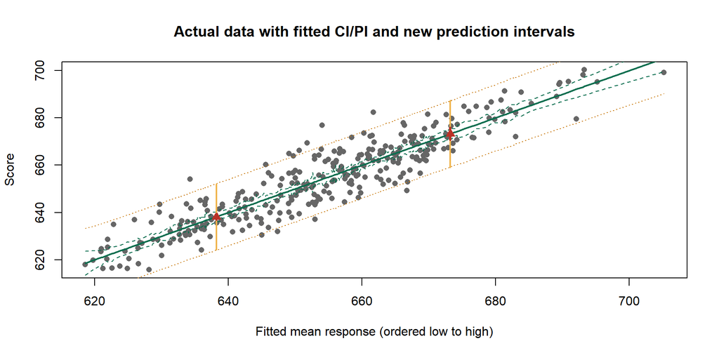

```r
# Overlay fitted means, CIs, and PIs on the cleaned CASchools training data.
plot(
  schools.fit.x,
  schools.train.new$score[schools.order],
  pch = 16,
  col = "gray40",
  xlab = "Fitted mean response (ordered low to high)",
  ylab = "Score",
  main = "Actual data with fitted CI/PI and new prediction intervals"
)

lines(schools.fit.x, schools.fit.x, col = "#0b6e4f", lwd = 2)
lines(schools.fit.x, schools.actual.conf[schools.order, "lwr"], col = "#0b6e4f", lty = 2)
lines(schools.fit.x, schools.actual.conf[schools.order, "upr"], col = "#0b6e4f", lty = 2)
lines(schools.fit.x, schools.actual.pred[schools.order, "lwr"], col = "#c97c10", lty = 3)
lines(schools.fit.x, schools.actual.pred[schools.order, "upr"], col = "#c97c10", lty = 3)

points(schools.new.fit, schools.new.fit, pch = 17, col = "#b83227", cex = 1.3)
segments(schools.new.fit, schools.pred[, "lwr"], schools.new.fit, schools.pred[, "upr"],
         col = "#f0b44c", lwd = 2)
segments(schools.new.fit, schools.conf[, "lwr"], schools.new.fit, schools.conf[, "upr"],
         col = "#b83227", lwd = 3)
```

- The x-axis is fitted mean response, sorted from low to high.
- New prediction cases now sit at their own fitted locations instead of being appended at the end.
- The spread around the fitted line is consistent with the wider orange prediction bands for new districts.

class: plot-slide

## CASchools: Predicted vs Actual (Test Set)

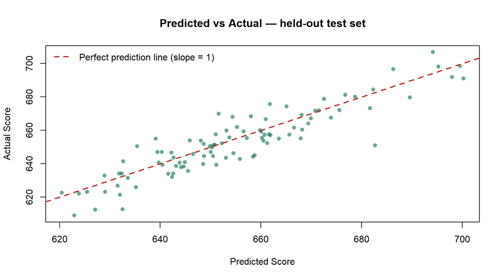

```r
# Final visual check on the held-out CASchools test set.
plot(
  schools.prediction,
  schools.test$score,
  pch = 16,
  col = adjustcolor("#0b6e4f", alpha.f = 0.6),
  xlab = "Predicted Score",
  ylab = "Actual Score",
  main = "Predicted vs Actual — held-out test set"
)
abline(0, 1, col = "#b83227", lwd = 2, lty = 2)
legend(
  "topleft",
  legend = "Perfect prediction line (slope = 1)",
  col = "#b83227",
  lty = 2,
  lwd = 2,
  bty = "n"
)
```

- The tight scatter around the diagonal shows the model generalizes well to unseen districts.
- Residual spread is roughly even across score levels, consistent with the Breusch-Pagan result.
- Any remaining deviations reflect unexplained district-level variation, not a systematic model failure.

class: center, middle, inverse

# Part II

## Finance Application

6 NYSE stocks, 3 years of close prices, and S&P 500 benchmarking

class: small-table compact

## Finance: Method Steps

```r
# Print the finance workflow table created in the setup chunk.
kable(finance.process, row.names = FALSE)
```

| Step | Detail |
| --- | --- |
| Pull close prices | Yahoo Finance, 2023-2025 |
| Convert to daily returns | Arithmetic daily returns |
| Annualize return and risk | Mean*252 and sd*sqrt(252) |
| Compare correlation to market | Corr(stock, SP500) |
| Plot cumulative returns | Growth of $1 over time |
| Run CAPM regressions | alpha, beta, and R2 |
| Track rolling beta | 60-day beta windows |
| Track rolling correlation | 60-day correlation windows |

- Returns, not raw prices, are the right object for comparison because the stocks trade at very different price levels.
- The finance results answer different questions: average performance, market linkage, regression exposure, and time variation.

class: small-table

## Finance: Stock Selection

```r
# Display the six stock choices and their sectors.
kable(finance.stocks, row.names = FALSE)
```

| Ticker | Company | Industry |
| --- | --- | --- |
| JPM | JPMorgan Chase | Financial Services |
| JNJ | Johnson & Johnson | Healthcare |
| XOM | Exxon Mobil | Energy |
| WMT | Walmart | Retail & Wholesale |
| CAT | Caterpillar | Industrials |
| BA | Boeing Company | Aerospace |

class: plot-slide

## Finance: Daily Return Distributions

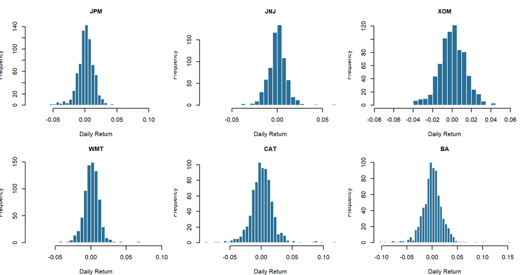

```r
# Compare daily return distributions for the six selected stocks.
par(mfrow = c(2, 3), mar = c(4, 3.5, 3, 1))

for (ticker in finance.stocks$Ticker) {
  hist(
    finance.ret.mat[, ticker],
    breaks = 40,
    col = "#2a6f97",
    border = "white",
    xlab = "Daily Return",
    main = ticker,
    cex.main = 1
  )
}
```

```r
par(mfrow = c(1, 1), mar = c(5.1, 4.1, 4.1, 2.1))
```

- All six stocks show fat-tailed return distributions — extreme days occur more often than a normal model predicts.
- The spread of each histogram confirms the annualized risk ordering shown in the return-risk plot.
- Comparing widths visually separates the more volatile names from the steadier defensive stocks.

class: plot-slide

## Finance: Close Prices

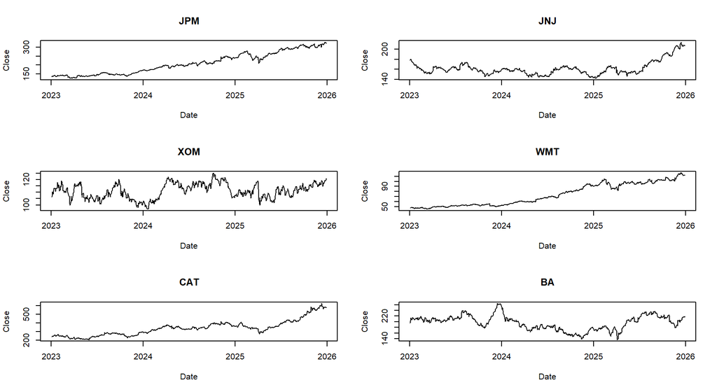

```r
# Plot raw closing prices for the six stocks only. SP500 is excluded here
# because it is a benchmark index, not a peer stock.
par(mfrow = c(3, 2))

plot(index(finance.close), as.numeric(finance.close[, "JPM"]),
     type = "l", xlab = "Date", ylab = "Close", main = "JPM")

plot(index(finance.close), as.numeric(finance.close[, "JNJ"]),
     type = "l", xlab = "Date", ylab = "Close", main = "JNJ")

plot(index(finance.close), as.numeric(finance.close[, "XOM"]),
     type = "l", xlab = "Date", ylab = "Close", main = "XOM")

plot(index(finance.close), as.numeric(finance.close[, "WMT"]),
     type = "l", xlab = "Date", ylab = "Close", main = "WMT")

plot(index(finance.close), as.numeric(finance.close[, "CAT"]),
     type = "l", xlab = "Date", ylab = "Close", main = "CAT")

plot(index(finance.close), as.numeric(finance.close[, "BA"]),
     type = "l", xlab = "Date", ylab = "Close", main = "BA")
```

```r
par(mfrow = c(1, 1))
```

- Raw close prices mainly show different scales and market regimes.
- The next comparisons switch to returns because raw dollar levels are not directly comparable across stocks.

class: plot-slide

## Finance: Annualized Return and Risk

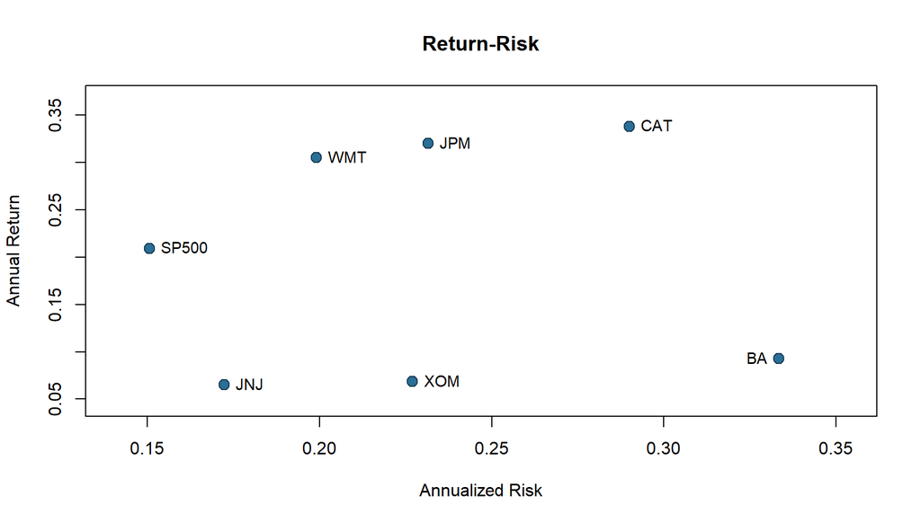

```r
# Risk-return scatter: x is annualized volatility, y is annualized mean return.
plot(
  finance.annual$Annual_Risk,
  finance.annual$Annual_Return,
  xlim = range(finance.annual$Annual_Risk) + c(-0.01, 0.02),
  ylim = range(finance.annual$Annual_Return) + c(-0.02, 0.03),
  pch = 21,
  bg = "#2a6f97",
  col = "#16384f",
  cex = 1.4,
  xlab = "Annualized Risk",
  ylab = "Annual Return",
  main = "Return-Risk"
)
text(
  finance.annual$Annual_Risk,
  finance.annual$Annual_Return,
  labels = finance.annual$Ticker,
  pos = finance.annual.label.pos,
  offset = 0.55,
  cex = 0.9,
  xpd = NA
)
```

- CAT has the strongest annualized return, while BA carries the most risk.
- JNJ is the defensive end of the group, so the chart separates aggressive from steadier names.

class: small-table plot-slide compact small-title

## Finance: Correlation with S&P 500 vs Risk and Return

.pull-left[

```r
# Table gives the numeric risk, return, and market-correlation values.
kable(finance.compare.display, row.names = FALSE)
```

| Ticker | Annual Return | Annual Risk | Corr with SP500 |
| --- | --- | --- | --- |
| JPM | 0.3198 | 0.2315 | 0.6023 |
| JNJ | 0.0650 | 0.1723 | 0.0811 |
| XOM | 0.0686 | 0.2270 | 0.2954 |
| WMT | 0.3049 | 0.1991 | 0.3494 |
| CAT | 0.3380 | 0.2899 | 0.6089 |
| BA | 0.0929 | 0.3333 | 0.4772 |

]

.pull-right[

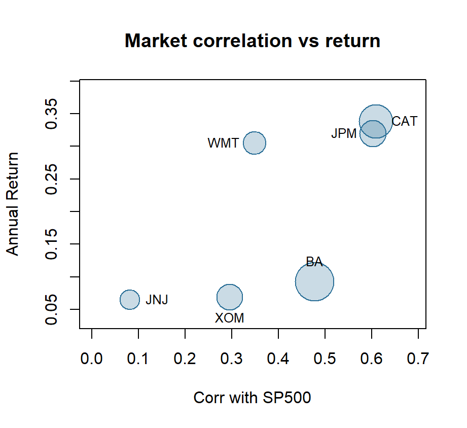

```r
# Bubble chart: position shows market correlation and return; bubble size
# represents annualized risk.
plot(
  finance.compare$Corr_SP500,
  finance.compare$Annual_Return,
  type = "n",
  xlim = range(finance.compare$Corr_SP500) + c(-0.08, 0.08),
  ylim = range(finance.compare$Annual_Return) + c(-0.03, 0.05),
  xlab = "Corr with SP500",
  ylab = "Annual Return",
  main = "Market correlation vs return"
)

symbols(
  finance.compare$Corr_SP500,
  finance.compare$Annual_Return,
  circles = finance.compare$Annual_Risk,
  inches = 0.2,
  add = TRUE,
  bg = adjustcolor("#2a6f97", alpha.f = 0.25),
  fg = "#2a6f97"
)

text(
  finance.compare$Corr_SP500,
  finance.compare$Annual_Return,
  labels = finance.compare$Ticker,
  pos = finance.label.pos,
  offset = 0.8,
  cex = 0.8,
  xpd = NA
)
```

]

- Horizontal position is correlation with the S&P 500, vertical position is annualized return, and bubble size reflects annualized risk.
- CAT is the most market-linked stock here, but that does not automatically make it the highest-return name.
- JNJ helps show that lower market linkage can pair with a very different return-risk profile.

class: plot-slide

## Finance: Linking Risk-Return and Market Correlation

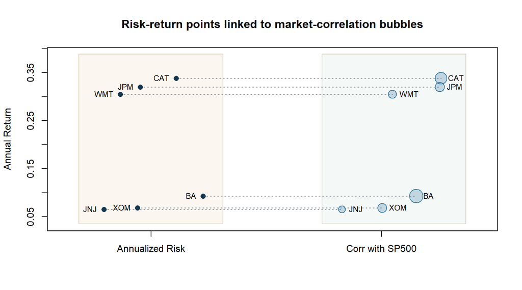

```r
# This custom plot puts two views on the same y-axis: risk-return on the left
# and market-correlation-return on the right. Dotted segments link each stock.
risk.x <- 0.8 + (finance.compare$Annual_Risk - min(finance.compare$Annual_Risk)) /
  diff(range(finance.compare$Annual_Risk)) * 1.0
corr.x <- 3.2 + (finance.compare$Corr_SP500 - min(finance.compare$Corr_SP500)) /
  diff(range(finance.compare$Corr_SP500)) * 1.0
ylims <- range(finance.compare$Annual_Return) + c(-0.03, 0.05)

plot(
  NA,
  xlim = c(0.4, 4.6),
  ylim = ylims,
  xaxt = "n",
  xlab = "",
  ylab = "Annual Return",
  main = "Risk-return points linked to market-correlation bubbles"
)

rect(0.55, ylims[1], 2.0, ylims[2], border = "#d9cdb7", col = adjustcolor("#f7efe1", alpha.f = 0.55))
rect(3.0, ylims[1], 4.45, ylims[2], border = "#d9cdb7", col = adjustcolor("#eef6f4", alpha.f = 0.65))
axis(1, at = c(1.275, 3.6), labels = c("Annualized Risk", "Corr with SP500"))

for (i in 1:nrow(finance.compare)) {
  segments(risk.x[i], finance.compare$Annual_Return[i], corr.x[i], finance.compare$Annual_Return[i],
           lty = 3, lwd = 1.5, col = adjustcolor("#7a8793", alpha.f = 0.8))
}

points(risk.x, finance.compare$Annual_Return, pch = 16, col = "#16384f", cex = 1.2)
symbols(
  corr.x,
  finance.compare$Annual_Return,
  circles = finance.compare$Annual_Risk,
  inches = 0.12,
  add = TRUE,
  bg = adjustcolor("#2a6f97", alpha.f = 0.25),
  fg = "#2a6f97"
)

text(risk.x, finance.compare$Annual_Return, labels = finance.compare$Ticker, pos = 2, offset = 0.6, cex = 0.8)
text(corr.x, finance.compare$Annual_Return, labels = finance.compare$Ticker, pos = 4, offset = 0.6, cex = 0.8)
```

- Dotted links connect each stock’s annual return across the risk view and the market-correlation view.
- This makes it easier to compare whether a stock’s return profile is lining up more with risk or with broad-market linkage.
- A stock can be very market-linked without having the most extreme risk position, so correlation and volatility are related but not the same.

class: plot-slide

## Finance: Correlation Heatmap

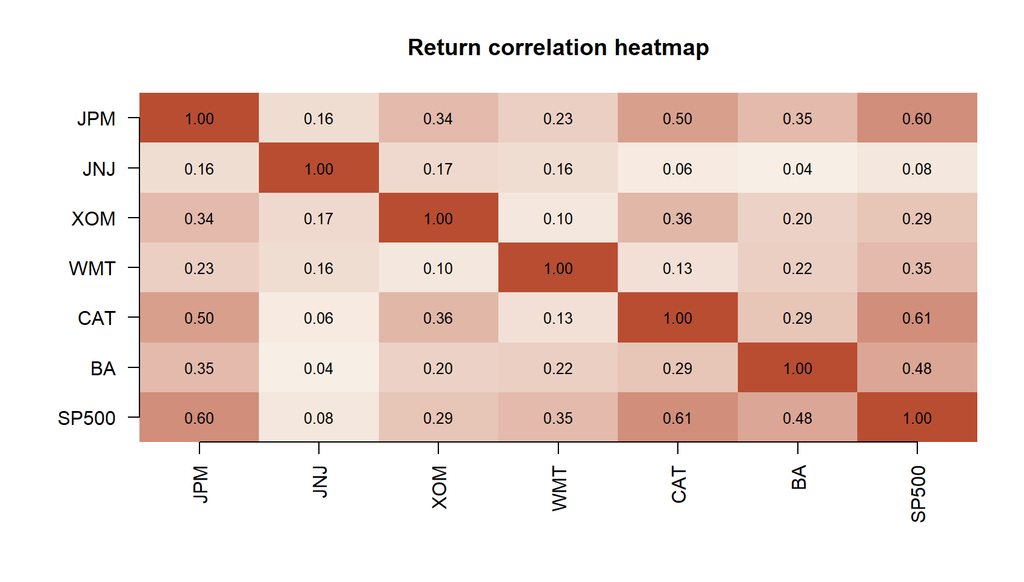

```r
# Heatmap version of the return-correlation matrix; warmer colors mean stronger
# positive return co-movement.
par(mar = c(6, 6, 4, 2))

image(
  1:ncol(finance.corr),
  1:nrow(finance.corr),
  t(finance.corr[nrow(finance.corr):1, ]),
  col = colorRampPalette(c("#16384f", "#fbf7ef", "#b84d32"))(100),
  zlim = c(-1, 1),
  axes = FALSE,
  xlab = "",
  ylab = "",
  main = "Return correlation heatmap"
)

axis(1, at = 1:ncol(finance.corr), labels = colnames(finance.corr), las = 2)
axis(2, at = 1:nrow(finance.corr), labels = rev(rownames(finance.corr)), las = 2)

for (i in 1:nrow(finance.corr)) {
  for (j in 1:ncol(finance.corr)) {
    text(j, nrow(finance.corr) - i + 1, labels = sprintf("%.2f", finance.corr[i, j]), cex = 0.8)
  }
}
```

```r
par(mar = c(5.1, 4.1, 4.1, 2.1))
```

- Warmer colors mean stronger positive correlation.
- Cooler colors mean weaker market co-movement.
- Correlation matters because diversification is weaker when all assets move together.
- The uneven color pattern shows that diversification benefit depends on which names are combined, not just how many names are held.

class: plot-slide

## Finance: Cumulative Returns

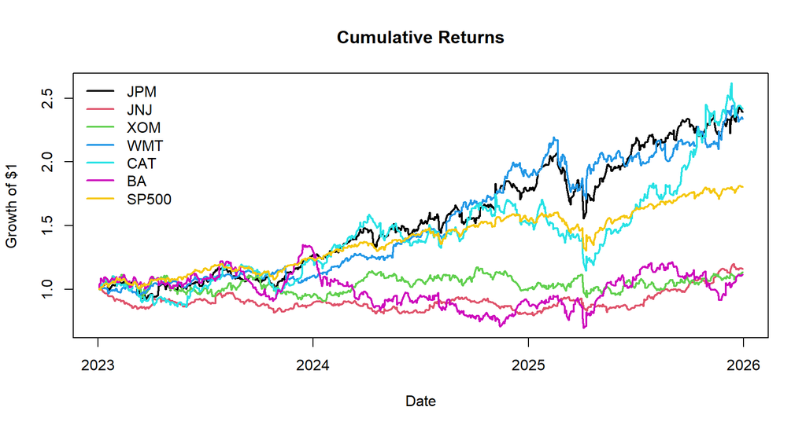

```r
# Convert daily returns into a growth-of-one-dollar path for each stock and
# the SP500 benchmark.
matplot(
  index(finance.cum),
  coredata(finance.cum),
  type = "l",
  lty = 1,
  lwd = 2,
  col = 1:7,
  xlab = "Date",
  ylab = "Growth of $1",
  main = "Cumulative Returns"
)

legend(
  "topleft",
  legend = colnames(finance.cum),
  col = 1:7,
  lty = 1,
  lwd = 2,
  bty = "n"
)
```

- CAT finishes with the strongest growth path, while BA trails the group.
- The path differences show why average return alone can hide very different investment experiences.

class: small-table

## Finance: Alpha, Beta, and R-Squared

```r
# CAPM summary table from six separate regressions of stock returns on SP500
# returns.
kable(finance.capm.display, row.names = FALSE)
```

| Ticker | Alpha Daily | Alpha Annual | Beta | R Squared |
| --- | --- | --- | --- | --- |
| JPM | 5e-04 | 0.1261 | 0.9257 | 0.3628 |
| JNJ | 2e-04 | 0.0456 | 0.0927 | 0.0066 |
| XOM | -1e-04 | -0.0246 | 0.4452 | 0.0873 |
| WMT | 8e-04 | 0.2083 | 0.4618 | 0.1221 |
| CAT | 4e-04 | 0.0929 | 1.1718 | 0.3707 |
| BA | -5e-04 | -0.1280 | 1.0558 | 0.2277 |

- `beta` measures sensitivity to market return.
- `alpha` measures abnormal return relative to the S&P 500.
- `R^2` measures how much of stock-return variation is explained by the market.
- CAT is the most market-sensitive name here, and CAT is the stock whose returns are most tightly tied to broad market movement.

class: plot-slide

## Finance: CAPM Fitted vs Actual Returns

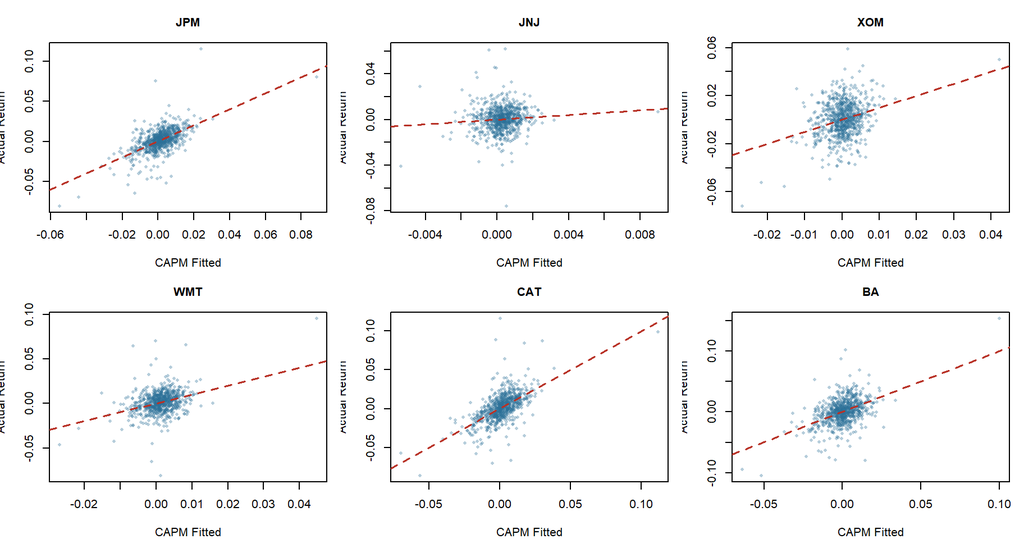

```r
# For each stock, re-fit the CAPM regression and compare actual daily returns
# against the fitted daily returns from the market factor.
par(mfrow = c(2, 3), mar = c(4, 3.5, 3, 1))

for (ticker in finance.stocks$Ticker) {
  model <- lm(finance.ret.mat[, ticker] ~ finance.ret.mat[, "SP500"])
  plot(
    fitted(model),
    finance.ret.mat[, ticker],
    pch = 16,
    col = adjustcolor("#2a6f97", alpha.f = 0.35),
    cex = 0.6,
    xlab = "CAPM Fitted",
    ylab = "Actual Return",
    main = ticker,
    cex.main = 1
  )
  abline(0, 1, col = "#b83227", lwd = 1.5, lty = 2)
}
```

```r
par(mfrow = c(1, 1), mar = c(5.1, 4.1, 4.1, 2.1))
```

- Stocks with higher R-squared cluster more tightly around the diagonal; lower R-squared stocks show wider scatter.
- The spread in each panel is the stock-specific variation the CAPM market factor cannot explain.
- This complements the R-squared column in the CAPM table by making the unexplained residual variation visible.

class: plot-slide

## Finance: Rolling 60-Day Beta

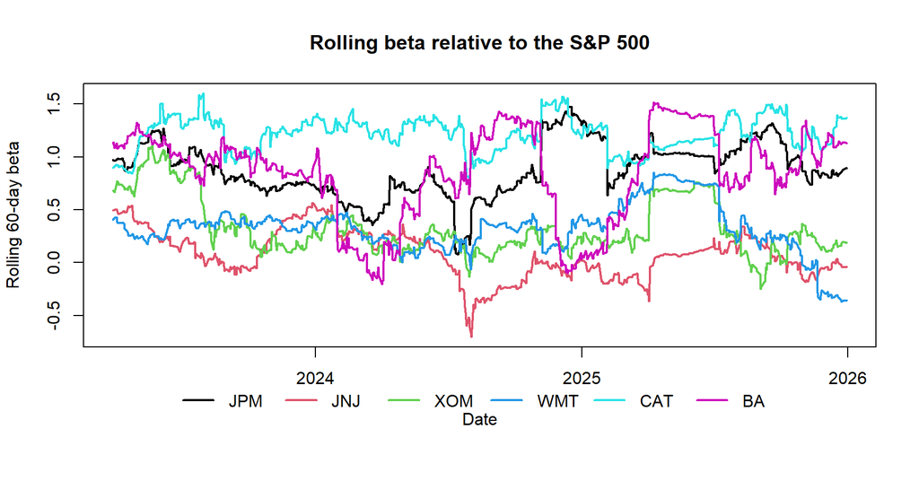

```r
# Plot the rolling market beta created in the setup chunk. Each point uses the
# prior 60 trading days, so changes show time-varying market exposure.
par(mar = c(7, 4.1, 4.1, 2.1))

matplot(
  index(finance.roll.beta),
  coredata(finance.roll.beta),
  type = "l",
  lty = 1,
  lwd = 2,
  col = 1:6,
  xlab = "Date",
  ylab = "Rolling 60-day beta",
  main = "Rolling beta relative to the S&P 500"
)

legend(
  "bottom",
  inset = c(0, -0.28),
  legend = colnames(finance.roll.beta),
  col = 1:6,
  lty = 1,
  lwd = 2,
  horiz = TRUE,
  xpd = NA,
  bty = "n"
)
```

```r
par(mar = c(5.1, 4.1, 4.1, 2.1))
```

- Beta above `1` means the stock moved more aggressively than the market in that 60-day window.
- Beta blends co-movement with relative volatility, so a rising line can mean tighter market linkage, larger stock swings, or both.
- A single full-sample beta misses these shifts, so rolling beta is more informative about changing exposure.

class: plot-slide

## Finance: Rolling 60-Day Correlation

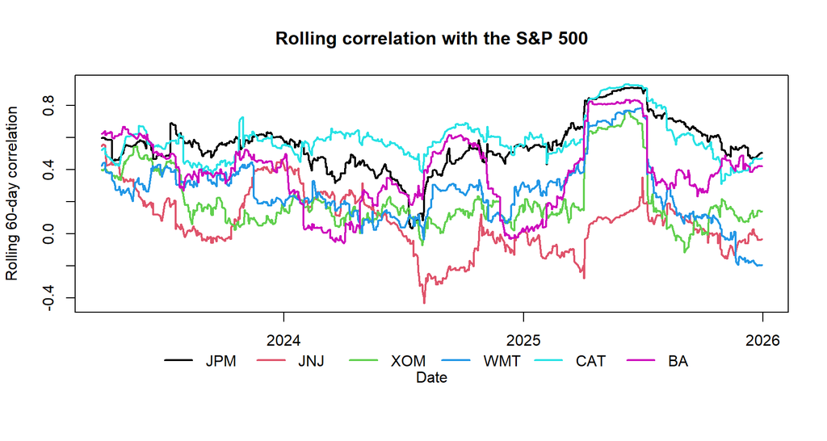

```r
# Plot the rolling 60-day correlation with SP500. This isolates co-movement
# from volatility, unlike beta.
par(mar = c(7, 4.1, 4.1, 2.1))

matplot(
  index(finance.roll.corr),
  coredata(finance.roll.corr),
  type = "l",
  lty = 1,
  lwd = 2,
  col = 1:6,
  xlab = "Date",
  ylab = "Rolling 60-day correlation",
  main = "Rolling correlation with the S&P 500"
)

legend(
  "bottom",
  inset = c(0, -0.28),
  legend = colnames(finance.roll.corr),
  col = 1:6,
  lty = 1,
  lwd = 2,
  horiz = TRUE,
  xpd = NA,
  bty = "n"
)
```

```r
par(mar = c(5.1, 4.1, 4.1, 2.1))
```

- Correlation isolates co-movement strength only, without the relative-volatility piece.
- Together, the rolling beta and rolling correlation plots show whether a stock became more market-linked because it moved more in sync with the S&P 500, because it got more volatile, or both.
- Comparing the two rolling plots separates “moves with the market” from “moves more violently than the market.”

class: center, middle, inverse

# Final Takeaways

- `HousePrices`: centered derived and interaction candidates enter before AIC/CV; the final post-Cook model uses Step 6 and keeps log_lotsize_c as derived terms plus garage_c:lotsize_1000_c as interactions.
- `HousePrices`: VIF is documented but not used as a pre-filter, and Box-Cox is treated as sensitivity evidence for a transformed response.
- `CASchools`: the final post-Cook model uses Step 12, keeps None as derived terms and low_income_pressure_c as interactions, and still points primarily to poverty, income, and district type.
- `CASchools`: Box-Cox is not strong enough to replace the original score scale.
- Finance: the six stocks occupy different risk-return positions, show different market linkage to the S&P 500, and that linkage changes over time in the rolling beta and rolling correlation plots.